# ANCOVA in Vocabulario Não Ensinado (Vocabulario Não Ensinado)

Geiser C. Challco geiser@alumni.usp.br

- Descriptive Statistics of Initial Data
- ANCOVA and Pairwise for one factor: **grupo**
  - Without remove non-normal data
  - Computing ANCOVA and PairWise After removing non-normal data (OK)
    - Plots for ancova
    - Checking linearity assumption
    - Checking normality and homogeneity
- ANCOVA and Pairwise for two factors **grupo:Sexo**
  - Without remove non-normal data
  - Computing ANCOVA and PairWise After removing non-normal data (OK)
    - Plots for ancova
    - Checking linearity assumption
    - Checking normality and homogeneity
- ANCOVA and Pairwise for two factors **grupo:Zona**
  - Without remove non-normal data
  - Computing ANCOVA and PairWise After removing non-normal data (OK)
    - Plots for ancova
    - Checking linearity assumption
    - Checking normality and homogeneity
- ANCOVA and Pairwise for two factors **grupo:Cor.Raca**
  - Without remove non-normal data
  - Computing ANCOVA and PairWise After removing non-normal data (OK)
    - Plots for ancova
    - Checking linearity assumption
    - Checking normality and homogeneity
- ANCOVA and Pairwise for two factors **grupo:vocab.non.teach.quintile**
  - Without remove non-normal data
  - Computing ANCOVA and PairWise After removing non-normal data (OK)
    - Plots for ancova
    - Checking linearity assumption
    - Checking normality and homogeneity
- Summary of Results
  - Descriptive Statistics
  - ANCOVA Table Comparison
  - PairWise Table Comparison
  - EMMS Table Comparison

**NOTE**:

- Teste ANCOVA para determinar se houve diferenças significativas no Vocabulario Não Ensinado (medido usando pre- e pos-testes).
- ANCOVA test to determine whether there were significant differences in Vocabulario Não Ensinado (measured using pre- and post-tests).

# Descriptive Statistics of Initial Data

```r
df <- get.descriptives(dat, c(dv.pre, dv.pos), c("grupo"),
                       include.global = T, symmetry.test = T, normality.test = F)
df <- plyr::rbind.fill(
  df, do.call(plyr::rbind.fill, lapply(lfatores2, FUN = function(f) {
    if (nrow(dat) > 0 && sum(!is.na(unique(dat[[f]]))) > 1)
      get.descriptives(dat, c(dv.pre,dv.pos), c("grupo", f),
                       symmetry.test = T, normality.test = F)
    }))
)
(df <- df[,c(fatores1[fatores1 %in% colnames(df)],"variable",
             colnames(df)[!colnames(df) %in% c(fatores1,"variable")])])
```

```
##           grupo Sexo   Zona Cor.Raca vocab.non.teach.quintile            variable   n   mean median min max
## 1      Controle <NA>   <NA>     <NA>                     <NA> vocab.non.teach.pre 100 22.530   23.5   5  39
## 2  Experimental <NA>   <NA>     <NA>                     <NA> vocab.non.teach.pre 181 23.425   25.0   3  36
## 3          <NA> <NA>   <NA>     <NA>                     <NA> vocab.non.teach.pre 281 23.107   24.0   3  39
## 4      Controle <NA>   <NA>     <NA>                     <NA> vocab.non.teach.pos 100 22.280   25.0   0  35
## 5  Experimental <NA>   <NA>     <NA>                     <NA> vocab.non.teach.pos 181 23.834   26.0   6  35
## 6          <NA> <NA>   <NA>     <NA>                     <NA> vocab.non.teach.pos 281 23.281   25.0   0  35
## 7      Controle    F   <NA>     <NA>                     <NA> vocab.non.teach.pre  53 23.189   24.0   5  39
## 8      Controle    M   <NA>     <NA>                     <NA> vocab.non.teach.pre  47 21.787   21.0  10  34
## 9  Experimental    F   <NA>     <NA>                     <NA> vocab.non.teach.pre  96 24.271   26.0   3  36
## 10 Experimental    M   <NA>     <NA>                     <NA> vocab.non.teach.pre  85 22.471   23.0   6  36
## 11     Controle    F   <NA>     <NA>                     <NA> vocab.non.teach.pos  53 23.566   26.0   0  35
## 12     Controle    M   <NA>     <NA>                     <NA> vocab.non.teach.pos  47 20.830   23.0   2  35
## 13 Experimental    F   <NA>     <NA>                     <NA> vocab.non.teach.pos  96 24.740   26.5   6  35
## 14 Experimental    M   <NA>     <NA>                     <NA> vocab.non.teach.pos  85 22.812   24.0   6  35
```

[output cut: 98 more lines]

| grupo | Sexo | Zona | Cor.Raca | vocab.non.teach.quintile | variable | n | mean | median | min | max | sd | se | ci | iqr | symmetry | skewness | kurtosis |
| --- | --- | --- | --- | --- | --- | --- | --- | --- | --- | --- | --- | --- | --- | --- | --- | --- | --- |
| Controle |  |  |  |  | vocab.non.teach.pre | 100 | 22.530 | 23.5 | 5 | 39 | 6.987 | 0.699 | 1.386 | 9.25 | YES | -0.377 | -0.346 |
| Experimental |  |  |  |  | vocab.non.teach.pre | 181 | 23.425 | 25.0 | 3 | 36 | 7.356 | 0.547 | 1.079 | 10.00 | NO | -0.568 | -0.347 |
|  |  |  |  |  | vocab.non.teach.pre | 281 | 23.107 | 24.0 | 3 | 39 | 7.227 | 0.431 | 0.849 | 10.00 | YES | -0.498 | -0.350 |
| Controle |  |  |  |  | vocab.non.teach.pos | 100 | 22.280 | 25.0 | 0 | 35 | 8.709 | 0.871 | 1.728 | 12.75 | NO | -0.634 | -0.644 |
| Experimental |  |  |  |  | vocab.non.teach.pos | 181 | 23.834 | 26.0 | 6 | 35 | 7.429 | 0.552 | 1.090 | 12.00 | NO | -0.576 | -0.645 |
|  |  |  |  |  | vocab.non.teach.pos | 281 | 23.281 | 25.0 | 0 | 35 | 7.928 | 0.473 | 0.931 | 11.00 | NO | -0.648 | -0.486 |
| Controle | F |  |  |  | vocab.non.teach.pre | 53 | 23.189 | 24.0 | 5 | 39 | 6.975 | 0.958 | 1.923 | 6.00 | NO | -0.653 | 0.548 |
| Controle | M |  |  |  | vocab.non.teach.pre | 47 | 21.787 | 21.0 | 10 | 34 | 7.000 | 1.021 | 2.055 | 10.50 | YES | -0.066 | -1.220 |
| Experimental | F |  |  |  | vocab.non.teach.pre | 96 | 24.271 | 26.0 | 3 | 36 | 7.572 | 0.773 | 1.534 | 11.25 | NO | -0.625 | -0.405 |
| Experimental | M |  |  |  | vocab.non.teach.pre | 85 | 22.471 | 23.0 | 6 | 36 | 7.026 | 0.762 | 1.516 | 9.00 | NO | -0.570 | -0.273 |
| Controle | F |  |  |  | vocab.non.teach.pos | 53 | 23.566 | 26.0 | 0 | 35 | 8.630 | 1.185 | 2.379 | 8.00 | NO | -0.944 | -0.062 |
| Controle | M |  |  |  | vocab.non.teach.pos | 47 | 20.830 | 23.0 | 2 | 35 | 8.659 | 1.263 | 2.542 | 14.00 | YES | -0.315 | -1.036 |
| Experimental | F |  |  |  | vocab.non.teach.pos | 96 | 24.740 | 26.5 | 6 | 35 | 7.409 | 0.756 | 1.501 | 10.50 | NO | -0.703 | -0.410 |
| Experimental | M |  |  |  | vocab.non.teach.pos | 85 | 22.812 | 24.0 | 6 | 35 | 7.361 | 0.798 | 1.588 | 12.00 | YES | -0.456 | -0.873 |
| Controle |  | Rural |  |  | vocab.non.teach.pre | 38 | 22.053 | 23.5 | 5 | 39 | 7.052 | 1.144 | 2.318 | 8.50 | YES | -0.210 | -0.113 |
| Controle |  | Urbana |  |  | vocab.non.teach.pre | 18 | 22.722 | 23.5 | 10 | 31 | 5.949 | 1.402 | 2.958 | 6.00 | NO | -0.694 | -0.476 |
| Controle |  |  |  |  | vocab.non.teach.pre | 44 | 22.864 | 23.5 | 5 | 35 | 7.435 | 1.121 | 2.261 | 11.00 | YES | -0.415 | -0.719 |
| Experimental |  | Rural |  |  | vocab.non.teach.pre | 56 | 23.018 | 25.0 | 6 | 33 | 7.320 | 0.978 | 1.960 | 10.00 | NO | -0.693 | -0.423 |
| Experimental |  | Urbana |  |  | vocab.non.teach.pre | 33 | 24.424 | 26.0 | 9 | 35 | 7.093 | 1.235 | 2.515 | 10.00 | NO | -0.658 | -0.522 |
| Experimental |  |  |  |  | vocab.non.teach.pre | 92 | 23.315 | 24.5 | 3 | 36 | 7.515 | 0.784 | 1.556 | 10.25 | YES | -0.449 | -0.376 |
| Controle |  | Rural |  |  | vocab.non.teach.pos | 38 | 23.026 | 25.0 | 2 | 34 | 8.146 | 1.321 | 2.677 | 7.00 | NO | -1.051 | 0.094 |
| Controle |  | Urbana |  |  | vocab.non.teach.pos | 18 | 25.778 | 26.0 | 11 | 35 | 6.320 | 1.490 | 3.143 | 5.75 | NO | -0.784 | 0.118 |
| Controle |  |  |  |  | vocab.non.teach.pos | 44 | 20.205 | 22.0 | 0 | 35 | 9.576 | 1.444 | 2.911 | 17.00 | YES | -0.134 | -1.227 |
| Experimental |  | Rural |  |  | vocab.non.teach.pos | 56 | 23.304 | 24.5 | 6 | 34 | 7.527 | 1.006 | 2.016 | 11.25 | NO | -0.534 | -0.727 |
| Experimental |  | Urbana |  |  | vocab.non.teach.pos | 33 | 25.303 | 26.0 | 9 | 35 | 7.218 | 1.256 | 2.559 | 10.00 | NO | -0.714 | -0.502 |
| Experimental |  |  |  |  | vocab.non.teach.pos | 92 | 23.630 | 26.0 | 6 | 35 | 7.456 | 0.777 | 1.544 | 11.25 | NO | -0.538 | -0.729 |
| Controle |  |  | Branca |  | vocab.non.teach.pre | 3 | 29.667 | 29.0 | 27 | 33 | 3.055 | 1.764 | 7.589 | 3.00 | few data | 0.000 | 0.000 |
| Controle |  |  | Indígena |  | vocab.non.teach.pre | 1 | 27.000 | 27.0 | 27 | 27 |  |  |  | 0.00 | few data | 0.000 | 0.000 |
| Controle |  |  | Parda |  | vocab.non.teach.pre | 38 | 22.526 | 22.5 | 5 | 39 | 7.012 | 1.138 | 2.305 | 7.75 | YES | -0.164 | -0.009 |
| Controle |  |  |  |  | vocab.non.teach.pre | 58 | 22.086 | 22.5 | 5 | 35 | 7.022 | 0.922 | 1.846 | 9.00 | YES | -0.425 | -0.699 |
| Experimental |  |  | Amarela |  | vocab.non.teach.pre | 1 | 20.000 | 20.0 | 20 | 20 |  |  |  | 0.00 | few data | 0.000 | 0.000 |
| Experimental |  |  | Branca |  | vocab.non.teach.pre | 19 | 24.947 | 25.0 | 15 | 33 | 5.441 | 1.248 | 2.623 | 10.00 | YES | -0.036 | -1.322 |
| Experimental |  |  | Parda |  | vocab.non.teach.pre | 53 | 22.283 | 24.0 | 6 | 35 | 8.468 | 1.163 | 2.334 | 11.00 | NO | -0.565 | -0.871 |
| Experimental |  |  |  |  | vocab.non.teach.pre | 108 | 23.750 | 25.0 | 3 | 36 | 7.066 | 0.680 | 1.348 | 10.25 | YES | -0.458 | -0.408 |
| Controle |  |  | Branca |  | vocab.non.teach.pos | 3 | 32.000 | 34.0 | 27 | 35 | 4.359 | 2.517 | 10.828 | 4.00 | few data | 0.000 | 0.000 |
| Controle |  |  | Indígena |  | vocab.non.teach.pos | 1 | 30.000 | 30.0 | 30 | 30 |  |  |  | 0.00 | few data | 0.000 | 0.000 |
| Controle |  |  | Parda |  | vocab.non.teach.pos | 38 | 21.947 | 25.5 | 0 | 34 | 9.303 | 1.509 | 3.058 | 13.25 | NO | -0.892 | -0.538 |
| Controle |  |  |  |  | vocab.non.teach.pos | 58 | 21.862 | 24.0 | 6 | 35 | 8.283 | 1.088 | 2.178 | 14.25 | YES | -0.325 | -1.004 |
| Experimental |  |  | Amarela |  | vocab.non.teach.pos | 1 | 20.000 | 20.0 | 20 | 20 |  |  |  | 0.00 | few data | 0.000 | 0.000 |
| Experimental |  |  | Branca |  | vocab.non.teach.pos | 19 | 24.263 | 26.0 | 11 | 35 | 7.023 | 1.611 | 3.385 | 10.00 | YES | -0.452 | -1.044 |
| Experimental |  |  | Parda |  | vocab.non.teach.pos | 53 | 23.698 | 25.0 | 6 | 34 | 7.941 | 1.091 | 2.189 | 12.00 | NO | -0.625 | -0.751 |
| Experimental |  |  |  |  | vocab.non.teach.pos | 108 | 23.861 | 26.0 | 6 | 35 | 7.329 | 0.705 | 1.398 | 10.50 | NO | -0.550 | -0.655 |
| Controle |  |  |  | 1st quintile | vocab.non.teach.pre | 14 | 10.357 | 10.5 | 5 | 13 | 2.620 | 0.700 | 1.513 | 2.00 | NO | -0.958 | -0.241 |
| Controle |  |  |  | 2nd quintile | vocab.non.teach.pre | 17 | 17.176 | 18.0 | 14 | 19 | 1.704 | 0.413 | 0.876 | 2.00 | NO | -0.614 | -1.056 |
| Controle |  |  |  | 3rd quintile | vocab.non.teach.pre | 25 | 22.120 | 22.0 | 20 | 24 | 1.333 | 0.267 | 0.550 | 2.00 | YES | 0.095 | -1.167 |
| Controle |  |  |  | 4th quintile | vocab.non.teach.pre | 29 | 26.897 | 27.0 | 25 | 29 | 1.319 | 0.245 | 0.502 | 2.00 | YES | 0.092 | -1.216 |
| Controle |  |  |  | 5th quintile | vocab.non.teach.pre | 15 | 32.200 | 31.0 | 30 | 39 | 2.455 | 0.634 | 1.360 | 2.50 | NO | 1.325 | 1.243 |
| Experimental |  |  |  | 1st quintile | vocab.non.teach.pre | 19 | 8.842 | 9.0 | 3 | 13 | 2.566 | 0.589 | 1.237 | 3.50 | YES | -0.376 | -0.654 |
| Experimental |  |  |  | 2nd quintile | vocab.non.teach.pre | 30 | 16.933 | 17.0 | 14 | 19 | 1.680 | 0.307 | 0.627 | 3.75 | YES | -0.068 | -1.573 |
| Experimental |  |  |  | 3rd quintile | vocab.non.teach.pre | 39 | 21.538 | 21.0 | 20 | 24 | 1.466 | 0.235 | 0.475 | 3.00 | YES | 0.268 | -1.487 |
| Experimental |  |  |  | 4th quintile | vocab.non.teach.pre | 48 | 26.854 | 27.0 | 25 | 29 | 1.399 | 0.202 | 0.406 | 2.00 | YES | 0.163 | -1.315 |
| Experimental |  |  |  | 5th quintile | vocab.non.teach.pre | 45 | 31.889 | 31.0 | 30 | 36 | 1.748 | 0.261 | 0.525 | 2.00 | NO | 0.765 | -0.451 |
| Controle |  |  |  | 1st quintile | vocab.non.teach.pos | 14 | 10.571 | 10.0 | 2 | 21 | 4.863 | 1.300 | 2.808 | 4.50 | YES | 0.451 | -0.282 |
| Controle |  |  |  | 2nd quintile | vocab.non.teach.pos | 17 | 20.412 | 22.0 | 0 | 32 | 9.063 | 2.198 | 4.660 | 14.00 | NO | -0.644 | -0.709 |
| Controle |  |  |  | 3rd quintile | vocab.non.teach.pos | 25 | 23.040 | 24.0 | 7 | 31 | 6.341 | 1.268 | 2.617 | 5.00 | NO | -1.229 | 0.890 |
| Controle |  |  |  | 4th quintile | vocab.non.teach.pos | 29 | 25.552 | 27.0 | 8 | 35 | 5.635 | 1.046 | 2.144 | 4.00 | NO | -1.379 | 2.352 |
| Controle |  |  |  | 5th quintile | vocab.non.teach.pos | 15 | 27.733 | 33.0 | 8 | 35 | 9.573 | 2.472 | 5.301 | 9.00 | NO | -1.071 | -0.573 |
| Experimental |  |  |  | 1st quintile | vocab.non.teach.pos | 19 | 13.421 | 13.0 | 6 | 29 | 6.167 | 1.415 | 2.973 | 8.00 | NO | 0.771 | -0.047 |
| Experimental |  |  |  | 2nd quintile | vocab.non.teach.pos | 30 | 17.633 | 17.0 | 10 | 29 | 4.522 | 0.826 | 1.688 | 6.00 | YES | 0.236 | -0.465 |
| Experimental |  |  |  | 3rd quintile | vocab.non.teach.pos | 39 | 21.897 | 23.0 | 6 | 30 | 5.134 | 0.822 | 1.664 | 5.50 | NO | -1.060 | 0.988 |
| Experimental |  |  |  | 4th quintile | vocab.non.teach.pos | 48 | 27.396 | 28.0 | 13 | 34 | 4.276 | 0.617 | 1.242 | 4.00 | NO | -1.350 | 1.892 |
| Experimental |  |  |  | 5th quintile | vocab.non.teach.pos | 45 | 30.244 | 31.0 | 12 | 35 | 4.711 | 0.702 | 1.415 | 4.00 | NO | -2.340 | 6.301 |

# ANCOVA and Pairwise for one factor: **grupo**

## Without remove non-normal data

```r
pdat = remove_group_data(dat[!is.na(dat[["grupo"]]),], "vocab.non.teach.pos", "grupo")

pdat.long <- rbind(pdat[,c("id","grupo")], pdat[,c("id","grupo")])
pdat.long[["time"]] <- c(rep("pre", nrow(pdat)), rep("pos", nrow(pdat)))
pdat.long[["time"]] <- factor(pdat.long[["time"]], c("pre","pos"))
pdat.long[["vocab.non.teach"]] <- c(pdat[["vocab.non.teach.pre"]], pdat[["vocab.non.teach.pos"]])

aov = anova_test(pdat, vocab.non.teach.pos ~ vocab.non.teach.pre + grupo)
laov[["grupo"]] <- get_anova_table(aov)
```

```r
pwc <- emmeans_test(pdat, vocab.non.teach.pos ~ grupo, covariate = vocab.non.teach.pre,
                    p.adjust.method = "bonferroni")
```

```r
pwc.long <- emmeans_test(dplyr::group_by_at(pdat.long, "grupo"),
                          vocab.non.teach ~ time,
                          p.adjust.method = "bonferroni")
lpwc[["grupo"]] <- plyr::rbind.fill(pwc, pwc.long)
```

```r
ds <- get.descriptives(pdat, "vocab.non.teach.pos", "grupo", covar = "vocab.non.teach.pre")
ds <- merge(ds[ds$variable != "vocab.non.teach.pre",],
            ds[ds$variable == "vocab.non.teach.pre", !colnames(ds) %in% c("variable")],
            by = "grupo", all.x = T, suffixes = c("", ".vocab.non.teach.pre"))
ds <- merge(get_emmeans(pwc), ds, by = "grupo", suffixes = c(".emms", ""))
ds <- ds[,c("grupo","n","mean.vocab.non.teach.pre","se.vocab.non.teach.pre","mean","se","emmean","se.emms")]

colnames(ds) <- c("grupo", "N", paste0(c("M","SE")," (pre)"),
                  paste0(c("M","SE"), " (unadj)"), paste0(c("M", "SE"), " (adj)"))

lemms[["grupo"]] <- ds
```

## Computing ANCOVA and PairWise After removing non-normal data (OK)

```r
wdat = pdat

res = residuals(lm(vocab.non.teach.pos ~ vocab.non.teach.pre + grupo, data = wdat))
non.normal = getNonNormal(res, wdat$id, plimit = 0.05)

wdat = wdat[!wdat$id %in% non.normal,]

wdat.long <- rbind(wdat[,c("id","grupo")], wdat[,c("id","grupo")])
wdat.long[["time"]] <- c(rep("pre", nrow(wdat)), rep("pos", nrow(wdat)))
wdat.long[["time"]] <- factor(wdat.long[["time"]], c("pre","pos"))
wdat.long[["vocab.non.teach"]] <- c(wdat[["vocab.non.teach.pre"]], wdat[["vocab.non.teach.pos"]])

ldat[["grupo"]] = wdat

(non.normal)
```

```
##  [1] "P1003" "P3654" "P996"  "P2192" "P2245" "P2232" "P2207" "P1006" "P1069" "P2251" "P1056" "P1057" "P2069"
## [14] "P2219" "P2135" "P2206" "P1066" "P2164" "P3658" "P2092" "P2195" "P2125" "P1012"
```

```r
aov = anova_test(wdat, vocab.non.teach.pos ~ vocab.non.teach.pre + grupo)
laov[["grupo"]] <- merge(get_anova_table(aov), laov[["grupo"]], by="Effect", suffixes = c("","'"))

(df = get_anova_table(aov))
```

```
## ANOVA Table (type II tests)
##
##                Effect DFn DFd       F        p p<.05   ges
## 1 vocab.non.teach.pre   1 255 638.001 2.35e-71     * 0.714
## 2               grupo   1 255   1.202 2.74e-01       0.005
```

| Effect | DFn | DFd | F | p | p<.05 | ges |
| --- | --- | --- | --- | --- | --- | --- |
| vocab.non.teach.pre | 1 | 255 | 638.001 | 0.000 | * | 0.714 |
| grupo | 1 | 255 | 1.202 | 0.274 |  | 0.005 |

| term | .y. | group1 | group2 | df | statistic | p | p.adj | p.adj.signif |
| --- | --- | --- | --- | --- | --- | --- | --- | --- |
| vocab.non.teach.pre*grupo | vocab.non.teach.pos | Controle | Experimental | 255 | 1.097 | 0.274 | 0.274 | ns |

```r
pwc.long <- emmeans_test(dplyr::group_by_at(wdat.long, "grupo"),
                         vocab.non.teach ~ time,
                         p.adjust.method = "bonferroni")
lpwc[["grupo"]] <- merge(plyr::rbind.fill(pwc, pwc.long), lpwc[["grupo"]], by=c("grupo","term",".y.","group1","group2"), suffixes = c("","'"))
```

| grupo | term | .y. | group1 | group2 | df | statistic | p | p.adj | p.adj.signif |
| --- | --- | --- | --- | --- | --- | --- | --- | --- | --- |
| Controle | time | vocab.non.teach | pre | pos | 512 | -1.565 | 0.118 | 0.118 | ns |
| Experimental | time | vocab.non.teach | pre | pos | 512 | -1.274 | 0.203 | 0.203 | ns |

```r
ds <- get.descriptives(wdat, "vocab.non.teach.pos", "grupo", covar = "vocab.non.teach.pre")
ds <- merge(ds[ds$variable != "vocab.non.teach.pre",],
            ds[ds$variable == "vocab.non.teach.pre", !colnames(ds) %in% c("variable")],
            by = "grupo", all.x = T, suffixes = c("", ".vocab.non.teach.pre"))
ds <- merge(get_emmeans(pwc), ds, by = "grupo", suffixes = c(".emms", ""))
ds <- ds[,c("grupo","n","mean.vocab.non.teach.pre","se.vocab.non.teach.pre","mean","se","emmean","se.emms")]

colnames(ds) <- c("grupo", "N", paste0(c("M","SE")," (pre)"),
                  paste0(c("M","SE"), " (unadj)"), paste0(c("M", "SE"), " (adj)"))

lemms[["grupo"]] <- merge(ds, lemms[["grupo"]], by=c("grupo"), suffixes = c("","'"))
```

| grupo | N | M (pre) | SE (pre) | M (unadj) | SE (unadj) | M (adj) | SE (adj) |
| --- | --- | --- | --- | --- | --- | --- | --- |
| Controle | 87 | 22.276 | 0.728 | 23.989 | 0.792 | 24.589 | 0.417 |
| Experimental | 171 | 23.339 | 0.564 | 24.333 | 0.549 | 24.028 | 0.297 |

### Plots for ancova

```r
plots <- oneWayAncovaPlots(
  wdat, "vocab.non.teach.pos", "grupo", aov, list("grupo"=pwc), addParam = c("mean_se"),
  font.label.size=10, step.increase=0.05, p.label="p.adj",
  subtitle = which(aov$Effect == "grupo"))
```

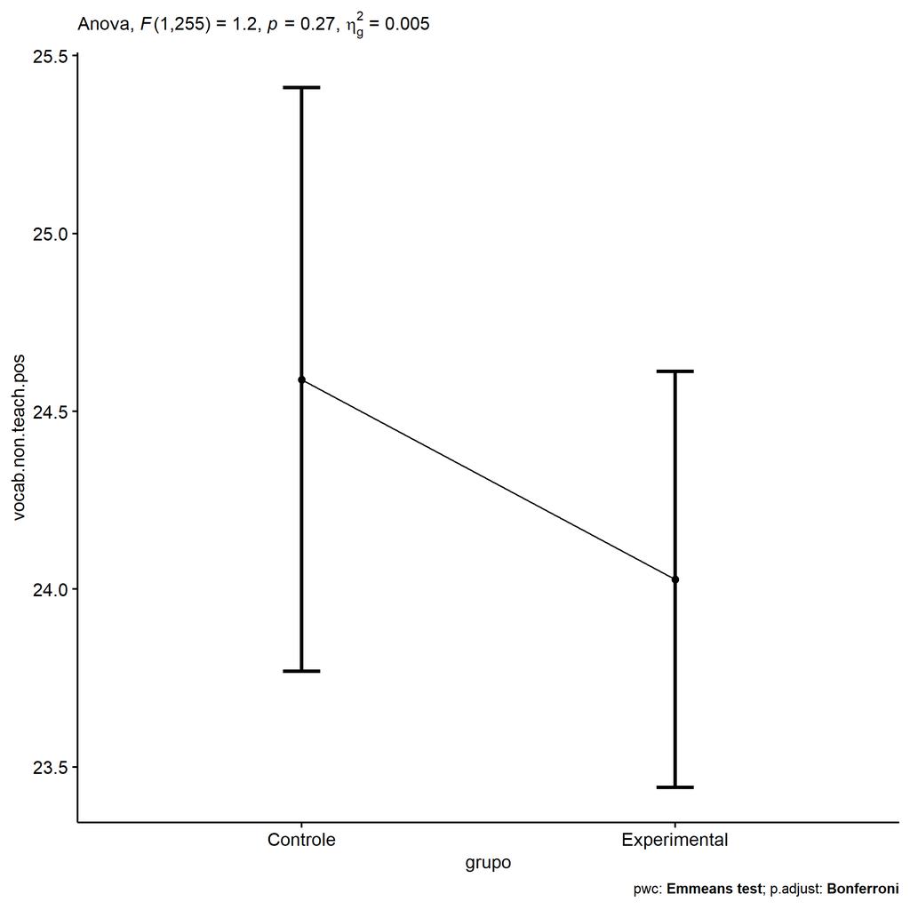

```r
if (!is.null(nrow(plots[["grupo"]]$data)))
  plots[["grupo"]] + ggplot2::scale_color_manual(values = color[["grupo"]])
```

```r
plots <- oneWayAncovaBoxPlots(
  wdat, "vocab.non.teach.pos", "grupo", aov, pwc, covar = "vocab.non.teach.pre",
  theme = "classic", color = color[["grupo"]],
  subtitle = which(aov$Effect == "grupo"))
```

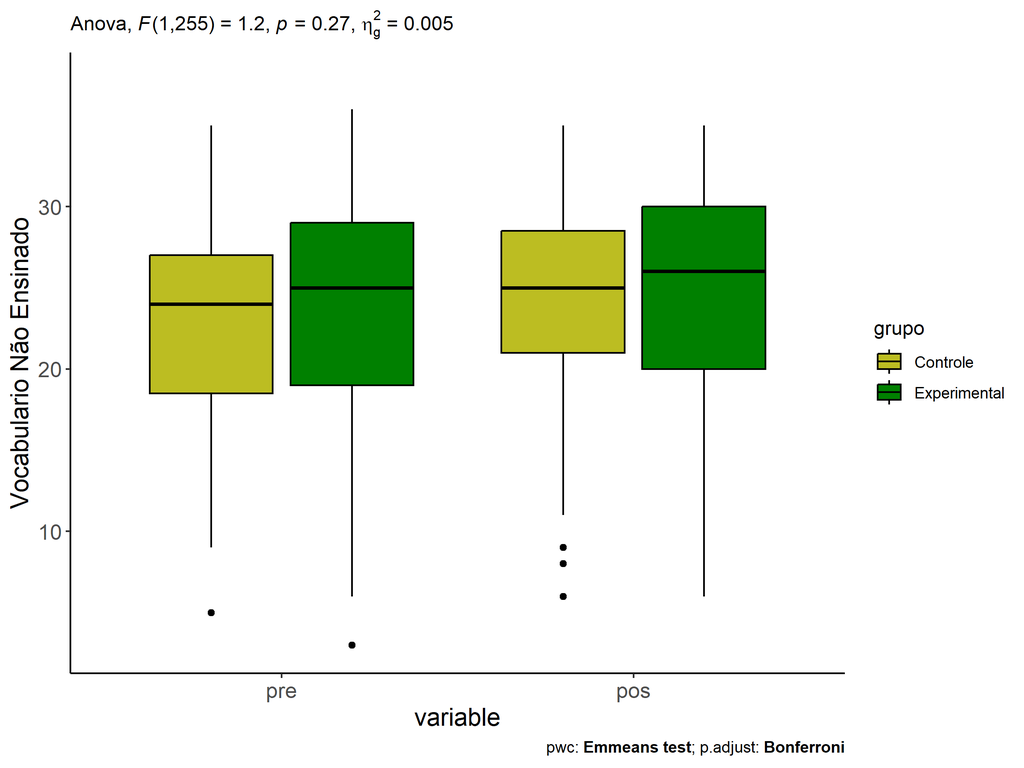

```r
if (length(unique(wdat[["grupo"]])) > 1)
  plots[["grupo"]] + ggplot2::ylab("Vocabulario Não Ensinado") + ggplot2::scale_x_discrete(labels=c('pre', 'pos'))
```

```r
if (length(unique(wdat.long[["grupo"]])) > 1)
  plots <- oneWayAncovaBoxPlots(
    wdat.long, "vocab.non.teach", "grupo", aov, pwc.long, pre.post = "time",
    theme = "classic", color = color$prepost)
```

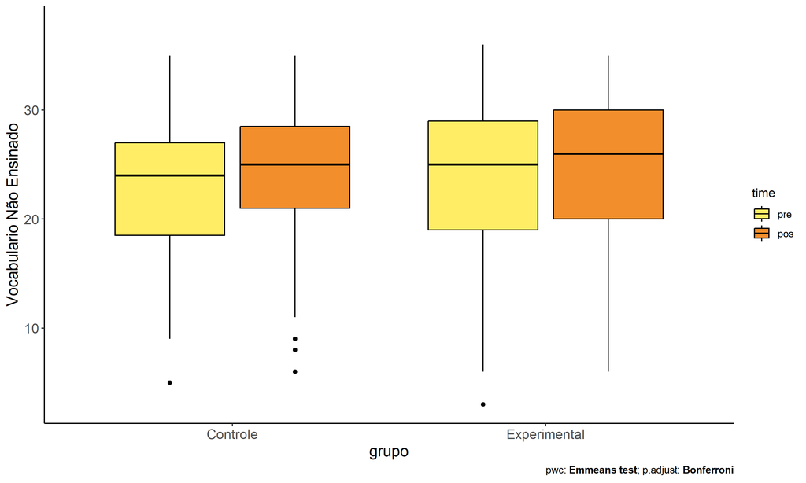

```r
if (length(unique(wdat.long[["grupo"]])) > 1)
  plots[["grupo"]] + ggplot2::ylab("Vocabulario Não Ensinado")
```

### Checking linearity assumption

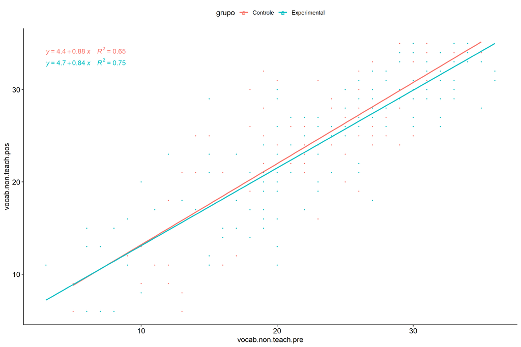

```r
ggscatter(wdat, x = "vocab.non.teach.pre", y = "vocab.non.teach.pos", size = 0.5,
          color = "grupo", add = "reg.line")+
  stat_regline_equation(
    aes(label =  paste(..eq.label.., ..rr.label.., sep = "~~~~"), color = grupo)
  )
```

### Checking normality and homogeneity

```r
res <- augment(lm(vocab.non.teach.pos ~ vocab.non.teach.pre + grupo, data = wdat))
```

```r
shapiro_test(res$.resid)
```

```
## # A tibble: 1 × 3
##   variable   statistic p.value
##   <chr>          <dbl>   <dbl>
## 1 res$.resid     0.994   0.331
```

```r
levene_test(res, .resid ~ grupo)
```

```
## # A tibble: 1 × 4
##     df1   df2 statistic      p
##   <int> <int>     <dbl>  <dbl>
## 1     1   256      3.56 0.0602
```

# ANCOVA and Pairwise for two factors **grupo:Sexo**

## Without remove non-normal data

```r
pdat = remove_group_data(dat[!is.na(dat[["grupo"]]) & !is.na(dat[["Sexo"]]),], "vocab.non.teach.pos", c("grupo","Sexo"))

pdat.long <- rbind(pdat[,c("id","grupo","Sexo")], pdat[,c("id","grupo","Sexo")])
pdat.long[["time"]] <- c(rep("pre", nrow(pdat)), rep("pos", nrow(pdat)))
pdat.long[["time"]] <- factor(pdat.long[["time"]], c("pre","pos"))
pdat.long[["vocab.non.teach"]] <- c(pdat[["vocab.non.teach.pre"]], pdat[["vocab.non.teach.pos"]])

aov = anova_test(pdat, vocab.non.teach.pos ~ vocab.non.teach.pre + grupo*Sexo)
laov[["grupo:Sexo"]] <- get_anova_table(aov)
```

```r
pwcs <- list()
pwcs[["Sexo"]] <- emmeans_test(
  group_by(pdat, grupo), vocab.non.teach.pos ~ Sexo,
  covariate = vocab.non.teach.pre, p.adjust.method = "bonferroni")
pwcs[["grupo"]] <- emmeans_test(
  group_by(pdat, Sexo), vocab.non.teach.pos ~ grupo,
  covariate = vocab.non.teach.pre, p.adjust.method = "bonferroni")

pwc <- plyr::rbind.fill(pwcs[["grupo"]], pwcs[["Sexo"]])
pwc <- pwc[,c("grupo","Sexo", colnames(pwc)[!colnames(pwc) %in% c("grupo","Sexo")])]
```

```r
pwc.long <- emmeans_test(dplyr::group_by_at(pdat.long, c("grupo","Sexo")),
                         vocab.non.teach ~ time,
                         p.adjust.method = "bonferroni")
lpwc[["grupo:Sexo"]] <- plyr::rbind.fill(pwc, pwc.long)
```

```r
ds <- get.descriptives(pdat, "vocab.non.teach.pos", c("grupo","Sexo"), covar = "vocab.non.teach.pre")
ds <- merge(ds[ds$variable != "vocab.non.teach.pre",],
            ds[ds$variable == "vocab.non.teach.pre", !colnames(ds) %in% c("variable")],
            by = c("grupo","Sexo"), all.x = T, suffixes = c("", ".vocab.non.teach.pre"))
ds <- merge(get_emmeans(pwcs[["grupo"]]), ds, by = c("grupo","Sexo"), suffixes = c(".emms", ""))
ds <- ds[,c("grupo","Sexo","n","mean.vocab.non.teach.pre","se.vocab.non.teach.pre","mean","se","emmean","se.emms")]

colnames(ds) <- c("grupo","Sexo", "N", paste0(c("M","SE")," (pre)"),
                  paste0(c("M","SE"), " (unadj)"), paste0(c("M", "SE"), " (adj)"))

lemms[["grupo:Sexo"]] <- ds
```

## Computing ANCOVA and PairWise After removing non-normal data (OK)

```r
wdat = pdat

res = residuals(lm(vocab.non.teach.pos ~ vocab.non.teach.pre + grupo*Sexo, data = wdat))
non.normal = getNonNormal(res, wdat$id, plimit = 0.05)

wdat = wdat[!wdat$id %in% non.normal,]

wdat.long <- rbind(wdat[,c("id","grupo","Sexo")], wdat[,c("id","grupo","Sexo")])
wdat.long[["time"]] <- c(rep("pre", nrow(wdat)), rep("pos", nrow(wdat)))
wdat.long[["time"]] <- factor(wdat.long[["time"]], c("pre","pos"))
wdat.long[["vocab.non.teach"]] <- c(wdat[["vocab.non.teach.pre"]], wdat[["vocab.non.teach.pos"]])


ldat[["grupo:Sexo"]] = wdat

(non.normal)
```

```
##  [1] "P1003" "P2192" "P996"  "P2245" "P1069" "P2207" "P1006" "P2251" "P1056" "P2232" "P3654" "P2069" "P1057"
## [14] "P2206" "P1066" "P2176" "P2219" "P3660" "P3159" "P1012" "P2164" "P2121" "P2161" "P2135" "P1029" "P2203"
## [27] "P2072" "P1050" "P2125" "P576"  "P1065"
```

```r
aov = anova_test(wdat, vocab.non.teach.pos ~ vocab.non.teach.pre + grupo*Sexo)
laov[["grupo:Sexo"]] <- merge(get_anova_table(aov), laov[["grupo:Sexo"]], by="Effect", suffixes = c("","'"))

(df = get_anova_table(aov))
```

```
## ANOVA Table (type II tests)
##
##                Effect DFn DFd       F        p p<.05   ges
## 1 vocab.non.teach.pre   1 245 601.988 6.14e-68     * 0.711
## 2               grupo   1 245   0.523 4.70e-01       0.002
## 3                Sexo   1 245   2.798 9.60e-02       0.011
## 4          grupo:Sexo   1 245   1.487 2.24e-01       0.006
```

| Effect | DFn | DFd | F | p | p<.05 | ges |
| --- | --- | --- | --- | --- | --- | --- |
| vocab.non.teach.pre | 1 | 245 | 601.988 | 0.000 | * | 0.711 |
| grupo | 1 | 245 | 0.523 | 0.470 |  | 0.002 |
| Sexo | 1 | 245 | 2.798 | 0.096 |  | 0.011 |
| grupo:Sexo | 1 | 245 | 1.487 | 0.224 |  | 0.006 |

```r
pwcs <- list()
pwcs[["Sexo"]] <- emmeans_test(
  group_by(wdat, grupo), vocab.non.teach.pos ~ Sexo,
  covariate = vocab.non.teach.pre, p.adjust.method = "bonferroni")
pwcs[["grupo"]] <- emmeans_test(
  group_by(wdat, Sexo), vocab.non.teach.pos ~ grupo,
  covariate = vocab.non.teach.pre, p.adjust.method = "bonferroni")

pwc <- plyr::rbind.fill(pwcs[["grupo"]], pwcs[["Sexo"]])
pwc <- pwc[,c("grupo","Sexo", colnames(pwc)[!colnames(pwc) %in% c("grupo","Sexo")])]
```

| grupo | Sexo | term | .y. | group1 | group2 | df | statistic | p | p.adj | p.adj.signif |
| --- | --- | --- | --- | --- | --- | --- | --- | --- | --- | --- |
|  | F | vocab.non.teach.pre*grupo | vocab.non.teach.pos | Controle | Experimental | 245 | 1.363 | 0.174 | 0.174 | ns |
|  | M | vocab.non.teach.pre*grupo | vocab.non.teach.pos | Controle | Experimental | 245 | -0.383 | 0.702 | 0.702 | ns |
| Controle |  | vocab.non.teach.pre*Sexo | vocab.non.teach.pos | F | M | 245 | 1.969 | 0.050 | 0.050 | ns |
| Experimental |  | vocab.non.teach.pre*Sexo | vocab.non.teach.pos | F | M | 245 | 0.655 | 0.513 | 0.513 | ns |

```r
pwc.long <- emmeans_test(dplyr::group_by_at(wdat.long, c("grupo","Sexo")),
                         vocab.non.teach ~ time,
                         p.adjust.method = "bonferroni")
lpwc[["grupo:Sexo"]] <- merge(plyr::rbind.fill(pwc, pwc.long), lpwc[["grupo:Sexo"]], by=c("grupo","Sexo","term",".y.","group1","group2"), suffixes = c("","'"))
```

| grupo | Sexo | term | .y. | group1 | group2 | df | statistic | p | p.adj | p.adj.signif |
| --- | --- | --- | --- | --- | --- | --- | --- | --- | --- | --- |
| Controle | F | time | vocab.non.teach | pre | pos | 492 | -1.534 | 0.126 | 0.126 | ns |
| Controle | M | time | vocab.non.teach | pre | pos | 492 | -0.612 | 0.541 | 0.541 | ns |
| Experimental | F | time | vocab.non.teach | pre | pos | 492 | -0.978 | 0.329 | 0.329 | ns |
| Experimental | M | time | vocab.non.teach | pre | pos | 492 | -0.906 | 0.366 | 0.366 | ns |

```r
ds <- get.descriptives(wdat, "vocab.non.teach.pos", c("grupo","Sexo"), covar = "vocab.non.teach.pre")
ds <- merge(ds[ds$variable != "vocab.non.teach.pre",],
            ds[ds$variable == "vocab.non.teach.pre", !colnames(ds) %in% c("variable")],
            by = c("grupo","Sexo"), all.x = T, suffixes = c("", ".vocab.non.teach.pre"))
ds <- merge(get_emmeans(pwcs[["grupo"]]), ds, by = c("grupo","Sexo"), suffixes = c(".emms", ""))
ds <- ds[,c("grupo","Sexo","n","mean.vocab.non.teach.pre","se.vocab.non.teach.pre","mean","se","emmean","se.emms")]

colnames(ds) <- c("grupo","Sexo", "N", paste0(c("M","SE")," (pre)"),
                  paste0(c("M","SE"), " (unadj)"), paste0(c("M", "SE"), " (adj)"))

lemms[["grupo:Sexo"]] <- merge(ds, lemms[["grupo:Sexo"]], by=c("grupo","Sexo"), suffixes = c("","'"))
```

| grupo | Sexo | N | M (pre) | SE (pre) | M (unadj) | SE (unadj) | M (adj) | SE (adj) |
| --- | --- | --- | --- | --- | --- | --- | --- | --- |
| Controle | F | 45 | 23.133 | 1.004 | 25.378 | 1.023 | 25.509 | 0.552 |
| Controle | M | 40 | 21.450 | 1.074 | 22.400 | 1.212 | 23.921 | 0.589 |
| Experimental | F | 86 | 24.733 | 0.788 | 25.767 | 0.711 | 24.578 | 0.402 |
| Experimental | M | 79 | 22.747 | 0.781 | 23.747 | 0.758 | 24.197 | 0.417 |

### Plots for ancova

```r
plots <- twoWayAncovaPlots(
  wdat, "vocab.non.teach.pos", c("grupo","Sexo"), aov, pwcs, addParam = c("mean_se"),
  font.label.size=10, step.increase=0.05, p.label="p.adj",
  subtitle = which(aov$Effect == "grupo:Sexo"))
```

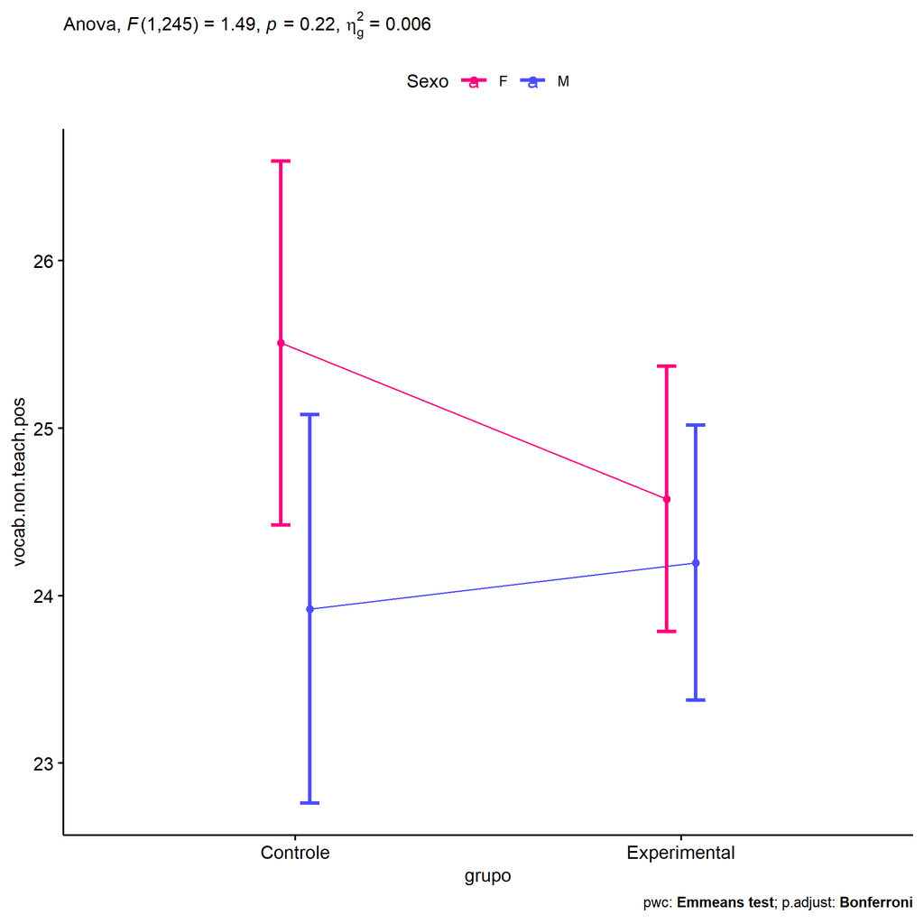

```r
if (!is.null(plots[["grupo"]]))
  plots[["grupo"]] + ggplot2::scale_color_manual(values = color[["Sexo"]])
```

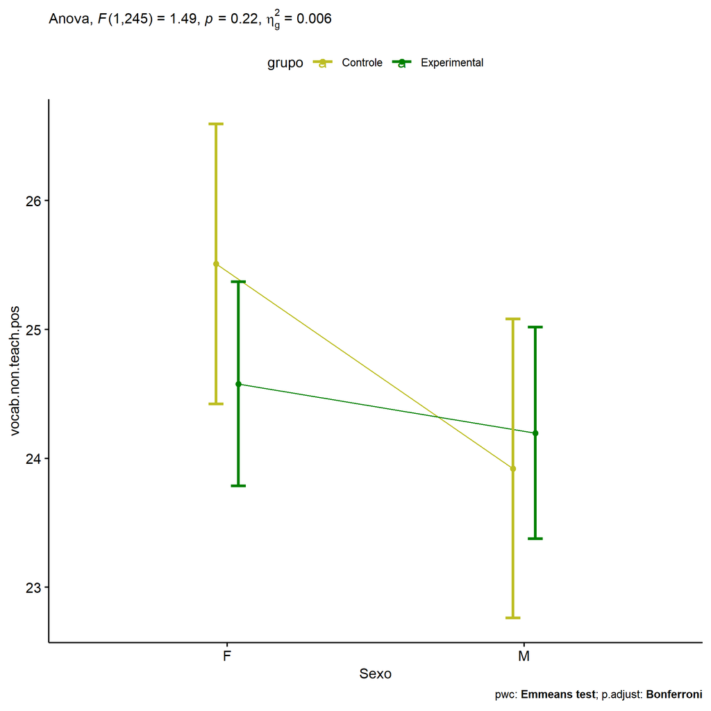

```r
if (!is.null(plots[["Sexo"]]))
  plots[["Sexo"]] + ggplot2::scale_color_manual(values = color[["grupo"]])
```

```r
plots <- twoWayAncovaBoxPlots(
  wdat, "vocab.non.teach.pos", c("grupo","Sexo"), aov, pwcs, covar = "vocab.non.teach.pre",
  theme = "classic", color = color[["grupo:Sexo"]],
  subtitle = which(aov$Effect == "grupo:Sexo"))
```

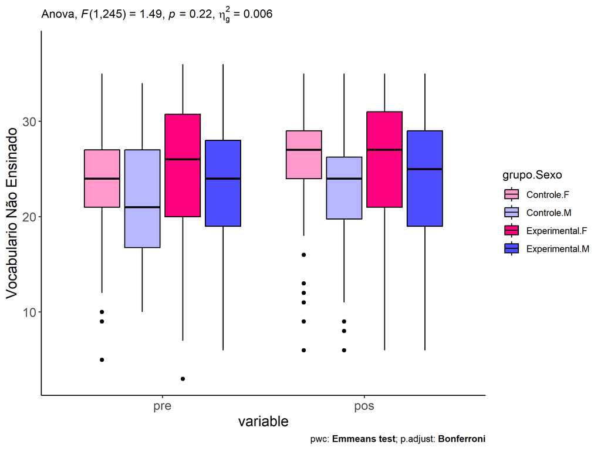

```r
plots[["grupo:Sexo"]] + ggplot2::ylab("Vocabulario Não Ensinado") + ggplot2::scale_x_discrete(labels=c('pre', 'pos'))
```

```r
plots <- twoWayAncovaBoxPlots(
  wdat.long, "vocab.non.teach", c("grupo","Sexo"), aov, pwc.long, pre.post = "time",
  theme = "classic", color = color$prepost)
```

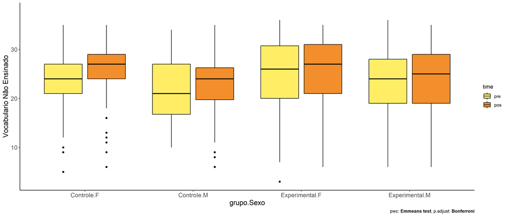

```r
plots[["grupo:Sexo"]] + ggplot2::ylab("Vocabulario Não Ensinado")
```

### Checking linearity assumption

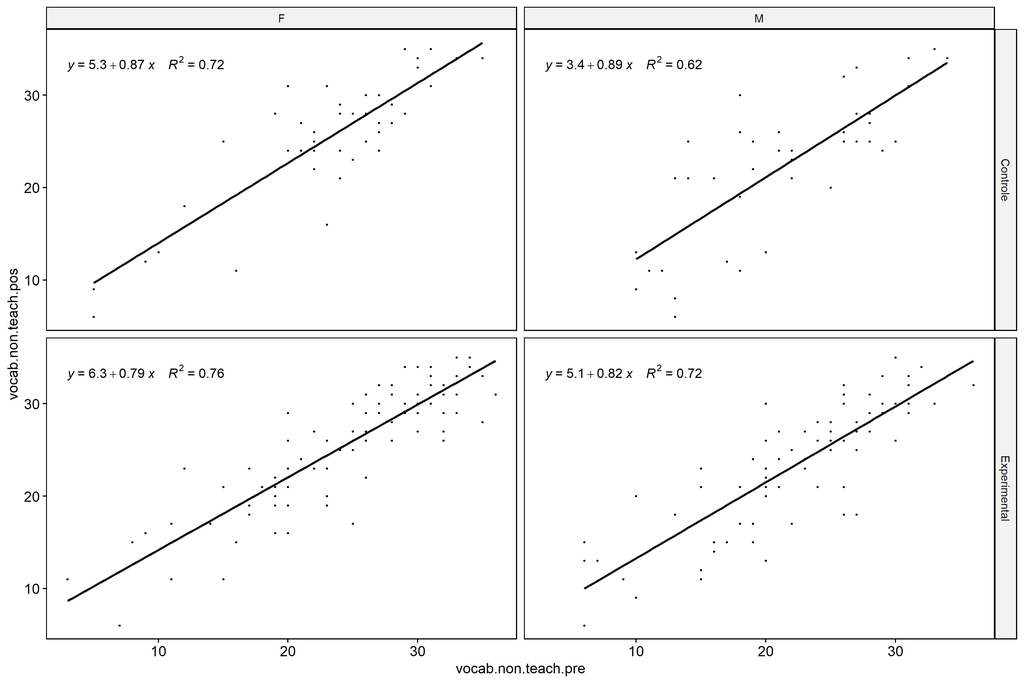

```r
ggscatter(wdat, x = "vocab.non.teach.pre", y = "vocab.non.teach.pos", size = 0.5,
          facet.by = c("grupo","Sexo"), add = "reg.line")+
  stat_regline_equation(
    aes(label =  paste(..eq.label.., ..rr.label.., sep = "~~~~"))
  )
```

### Checking normality and homogeneity

```r
res <- augment(lm(vocab.non.teach.pos ~ vocab.non.teach.pre + grupo*Sexo, data = wdat))
```

```r
shapiro_test(res$.resid)
```

```
## # A tibble: 1 × 3
##   variable   statistic p.value
##   <chr>          <dbl>   <dbl>
## 1 res$.resid     0.991   0.134
```

```r
levene_test(res, .resid ~ grupo*Sexo)
```

```
## # A tibble: 1 × 4
##     df1   df2 statistic      p
##   <int> <int>     <dbl>  <dbl>
## 1     3   246      2.51 0.0594
```

# ANCOVA and Pairwise for two factors **grupo:Zona**

## Without remove non-normal data

```r
pdat = remove_group_data(dat[!is.na(dat[["grupo"]]) & !is.na(dat[["Zona"]]),], "vocab.non.teach.pos", c("grupo","Zona"))

pdat.long <- rbind(pdat[,c("id","grupo","Zona")], pdat[,c("id","grupo","Zona")])
pdat.long[["time"]] <- c(rep("pre", nrow(pdat)), rep("pos", nrow(pdat)))
pdat.long[["time"]] <- factor(pdat.long[["time"]], c("pre","pos"))
pdat.long[["vocab.non.teach"]] <- c(pdat[["vocab.non.teach.pre"]], pdat[["vocab.non.teach.pos"]])

aov = anova_test(pdat, vocab.non.teach.pos ~ vocab.non.teach.pre + grupo*Zona)
laov[["grupo:Zona"]] <- get_anova_table(aov)
```

```r
pwcs <- list()
pwcs[["Zona"]] <- emmeans_test(
  group_by(pdat, grupo), vocab.non.teach.pos ~ Zona,
  covariate = vocab.non.teach.pre, p.adjust.method = "bonferroni")
pwcs[["grupo"]] <- emmeans_test(
  group_by(pdat, Zona), vocab.non.teach.pos ~ grupo,
  covariate = vocab.non.teach.pre, p.adjust.method = "bonferroni")

pwc <- plyr::rbind.fill(pwcs[["grupo"]], pwcs[["Zona"]])
pwc <- pwc[,c("grupo","Zona", colnames(pwc)[!colnames(pwc) %in% c("grupo","Zona")])]
```

```r
pwc.long <- emmeans_test(dplyr::group_by_at(pdat.long, c("grupo","Zona")),
                         vocab.non.teach ~ time,
                         p.adjust.method = "bonferroni")
lpwc[["grupo:Zona"]] <- plyr::rbind.fill(pwc, pwc.long)
```

```r
ds <- get.descriptives(pdat, "vocab.non.teach.pos", c("grupo","Zona"), covar = "vocab.non.teach.pre")
ds <- merge(ds[ds$variable != "vocab.non.teach.pre",],
            ds[ds$variable == "vocab.non.teach.pre", !colnames(ds) %in% c("variable")],
            by = c("grupo","Zona"), all.x = T, suffixes = c("", ".vocab.non.teach.pre"))
ds <- merge(get_emmeans(pwcs[["grupo"]]), ds, by = c("grupo","Zona"), suffixes = c(".emms", ""))
ds <- ds[,c("grupo","Zona","n","mean.vocab.non.teach.pre","se.vocab.non.teach.pre","mean","se","emmean","se.emms")]

colnames(ds) <- c("grupo","Zona", "N", paste0(c("M","SE")," (pre)"),
                  paste0(c("M","SE"), " (unadj)"), paste0(c("M", "SE"), " (adj)"))

lemms[["grupo:Zona"]] <- ds
```

## Computing ANCOVA and PairWise After removing non-normal data (OK)

```r
wdat = pdat

res = residuals(lm(vocab.non.teach.pos ~ vocab.non.teach.pre + grupo*Zona, data = wdat))
non.normal = getNonNormal(res, wdat$id, plimit = 0.05)

wdat = wdat[!wdat$id %in% non.normal,]

wdat.long <- rbind(wdat[,c("id","grupo","Zona")], wdat[,c("id","grupo","Zona")])
wdat.long[["time"]] <- c(rep("pre", nrow(wdat)), rep("pos", nrow(wdat)))
wdat.long[["time"]] <- factor(wdat.long[["time"]], c("pre","pos"))
wdat.long[["vocab.non.teach"]] <- c(wdat[["vocab.non.teach.pre"]], wdat[["vocab.non.teach.pos"]])


ldat[["grupo:Zona"]] = wdat

(non.normal)
```

```
## [1] "P2207" "P1056" "P3654"
```

```r
aov = anova_test(wdat, vocab.non.teach.pos ~ vocab.non.teach.pre + grupo*Zona)
laov[["grupo:Zona"]] <- merge(get_anova_table(aov), laov[["grupo:Zona"]], by="Effect", suffixes = c("","'"))

(df = get_anova_table(aov))
```

```
## ANOVA Table (type II tests)
##
##                Effect DFn DFd       F        p p<.05   ges
## 1 vocab.non.teach.pre   1 137 264.406 8.74e-34     * 0.659
## 2               grupo   1 137   1.310 2.54e-01       0.009
## 3                Zona   1 137   0.946 3.32e-01       0.007
## 4          grupo:Zona   1 137   1.086 2.99e-01       0.008
```

| Effect | DFn | DFd | F | p | p<.05 | ges |
| --- | --- | --- | --- | --- | --- | --- |
| vocab.non.teach.pre | 1 | 137 | 264.406 | 0.000 | * | 0.659 |
| grupo | 1 | 137 | 1.310 | 0.254 |  | 0.009 |
| Zona | 1 | 137 | 0.946 | 0.332 |  | 0.007 |
| grupo:Zona | 1 | 137 | 1.086 | 0.299 |  | 0.008 |

```r
pwcs <- list()
pwcs[["Zona"]] <- emmeans_test(
  group_by(wdat, grupo), vocab.non.teach.pos ~ Zona,
  covariate = vocab.non.teach.pre, p.adjust.method = "bonferroni")
pwcs[["grupo"]] <- emmeans_test(
  group_by(wdat, Zona), vocab.non.teach.pos ~ grupo,
  covariate = vocab.non.teach.pre, p.adjust.method = "bonferroni")

pwc <- plyr::rbind.fill(pwcs[["grupo"]], pwcs[["Zona"]])
pwc <- pwc[,c("grupo","Zona", colnames(pwc)[!colnames(pwc) %in% c("grupo","Zona")])]
```

| grupo | Zona | term | .y. | group1 | group2 | df | statistic | p | p.adj | p.adj.signif |
| --- | --- | --- | --- | --- | --- | --- | --- | --- | --- | --- |
|  | Rural | vocab.non.teach.pre*grupo | vocab.non.teach.pos | Controle | Experimental | 137 | 0.315 | 0.753 | 0.753 | ns |
|  | Urbana | vocab.non.teach.pre*grupo | vocab.non.teach.pos | Controle | Experimental | 137 | 1.516 | 0.132 | 0.132 | ns |
| Controle |  | vocab.non.teach.pre*Zona | vocab.non.teach.pos | Rural | Urbana | 137 | -1.420 | 0.158 | 0.158 | ns |
| Experimental |  | vocab.non.teach.pre*Zona | vocab.non.teach.pos | Rural | Urbana | 137 | -0.135 | 0.893 | 0.893 | ns |

```r
pwc.long <- emmeans_test(dplyr::group_by_at(wdat.long, c("grupo","Zona")),
                         vocab.non.teach ~ time,
                         p.adjust.method = "bonferroni")
lpwc[["grupo:Zona"]] <- merge(plyr::rbind.fill(pwc, pwc.long), lpwc[["grupo:Zona"]], by=c("grupo","Zona","term",".y.","group1","group2"), suffixes = c("","'"))
```

| grupo | Zona | term | .y. | group1 | group2 | df | statistic | p | p.adj | p.adj.signif |
| --- | --- | --- | --- | --- | --- | --- | --- | --- | --- | --- |
| Controle | Rural | time | vocab.non.teach | pre | pos | 276 | -0.842 | 0.401 | 0.401 | ns |
| Controle | Urbana | time | vocab.non.teach | pre | pos | 276 | -1.276 | 0.203 | 0.203 | ns |
| Experimental | Rural | time | vocab.non.teach | pre | pos | 276 | -0.737 | 0.462 | 0.462 | ns |
| Experimental | Urbana | time | vocab.non.teach | pre | pos | 276 | -0.497 | 0.620 | 0.620 | ns |

```r
ds <- get.descriptives(wdat, "vocab.non.teach.pos", c("grupo","Zona"), covar = "vocab.non.teach.pre")
ds <- merge(ds[ds$variable != "vocab.non.teach.pre",],
            ds[ds$variable == "vocab.non.teach.pre", !colnames(ds) %in% c("variable")],
            by = c("grupo","Zona"), all.x = T, suffixes = c("", ".vocab.non.teach.pre"))
ds <- merge(get_emmeans(pwcs[["grupo"]]), ds, by = c("grupo","Zona"), suffixes = c(".emms", ""))
ds <- ds[,c("grupo","Zona","n","mean.vocab.non.teach.pre","se.vocab.non.teach.pre","mean","se","emmean","se.emms")]

colnames(ds) <- c("grupo","Zona", "N", paste0(c("M","SE")," (pre)"),
                  paste0(c("M","SE"), " (unadj)"), paste0(c("M", "SE"), " (adj)"))

lemms[["grupo:Zona"]] <- merge(ds, lemms[["grupo:Zona"]], by=c("grupo","Zona"), suffixes = c("","'"))
```

| grupo | Zona | N | M (pre) | SE (pre) | M (unadj) | SE (unadj) | M (adj) | SE (adj) |
| --- | --- | --- | --- | --- | --- | --- | --- | --- |
| Controle | Rural | 37 | 22.054 | 1.175 | 23.459 | 1.283 | 24.200 | 0.708 |
| Controle | Urbana | 18 | 22.722 | 1.402 | 25.778 | 1.490 | 25.953 | 1.013 |
| Experimental | Rural | 54 | 22.685 | 0.985 | 23.704 | 1.002 | 23.910 | 0.585 |
| Experimental | Urbana | 33 | 24.424 | 1.235 | 25.303 | 1.256 | 24.039 | 0.752 |

### Plots for ancova

```r
plots <- twoWayAncovaPlots(
  wdat, "vocab.non.teach.pos", c("grupo","Zona"), aov, pwcs, addParam = c("mean_se"),
  font.label.size=10, step.increase=0.05, p.label="p.adj",
  subtitle = which(aov$Effect == "grupo:Zona"))
```

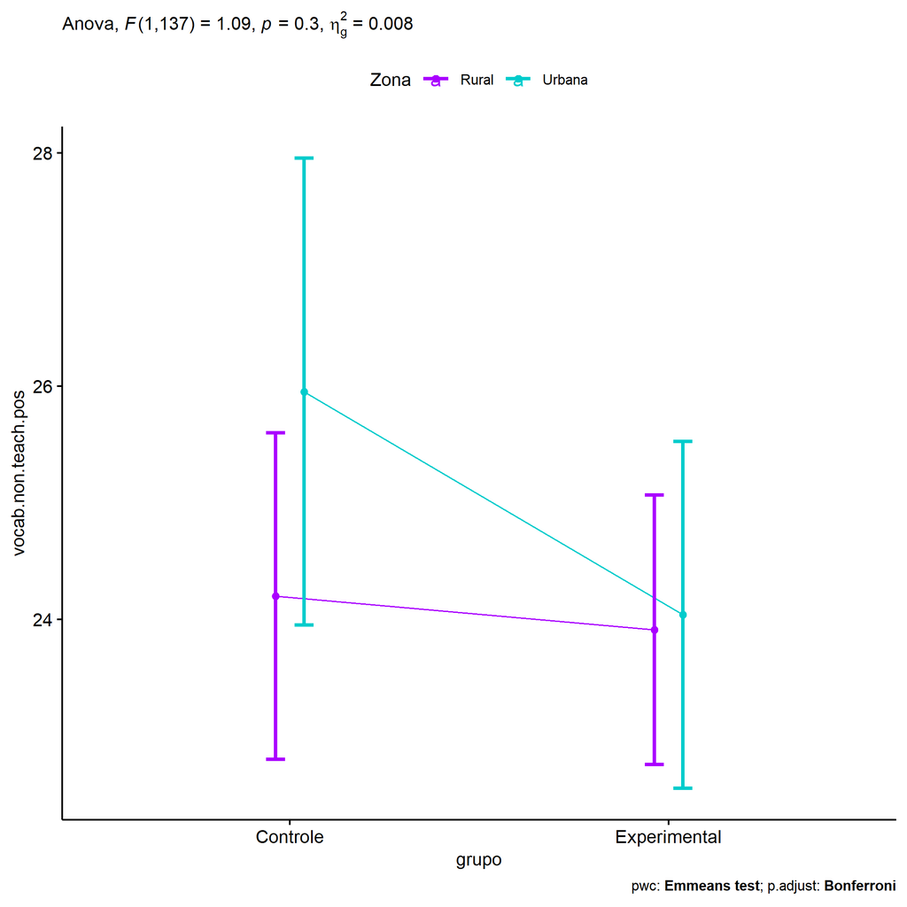

```r
if (!is.null(plots[["grupo"]]))
  plots[["grupo"]] + ggplot2::scale_color_manual(values = color[["Zona"]])
```

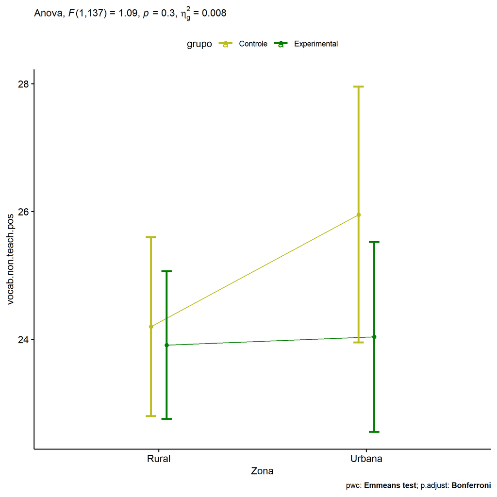

```r
if (!is.null(plots[["Zona"]]))
  plots[["Zona"]] + ggplot2::scale_color_manual(values = color[["grupo"]])
```

```r
plots <- twoWayAncovaBoxPlots(
  wdat, "vocab.non.teach.pos", c("grupo","Zona"), aov, pwcs, covar = "vocab.non.teach.pre",
  theme = "classic", color = color[["grupo:Zona"]],
  subtitle = which(aov$Effect == "grupo:Zona"))
```

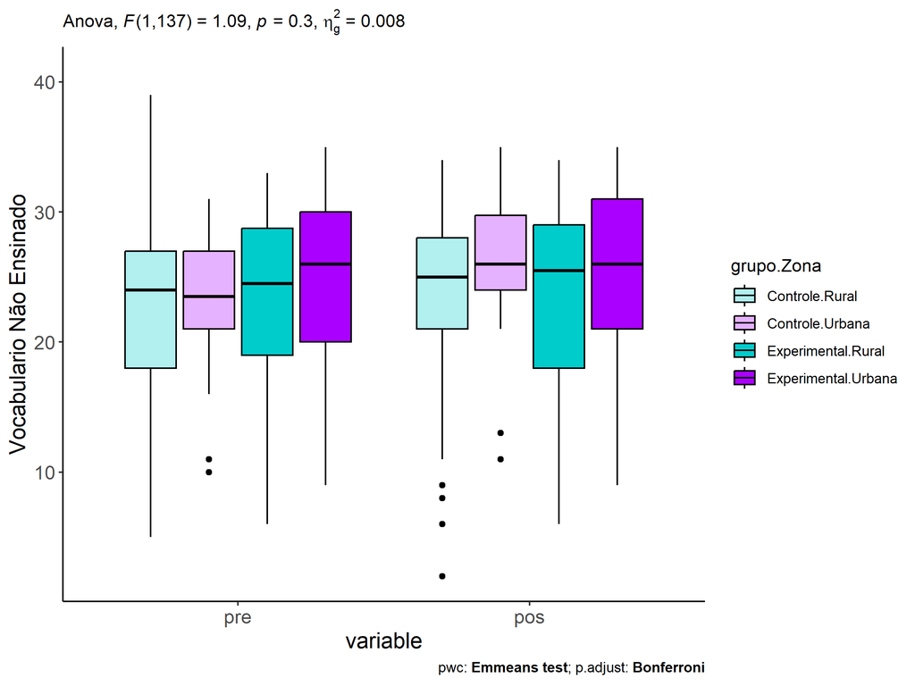

```r
plots[["grupo:Zona"]] + ggplot2::ylab("Vocabulario Não Ensinado") + ggplot2::scale_x_discrete(labels=c('pre', 'pos'))
```

```r
plots <- twoWayAncovaBoxPlots(
  wdat.long, "vocab.non.teach", c("grupo","Zona"), aov, pwc.long, pre.post = "time",
  theme = "classic", color = color$prepost)
```

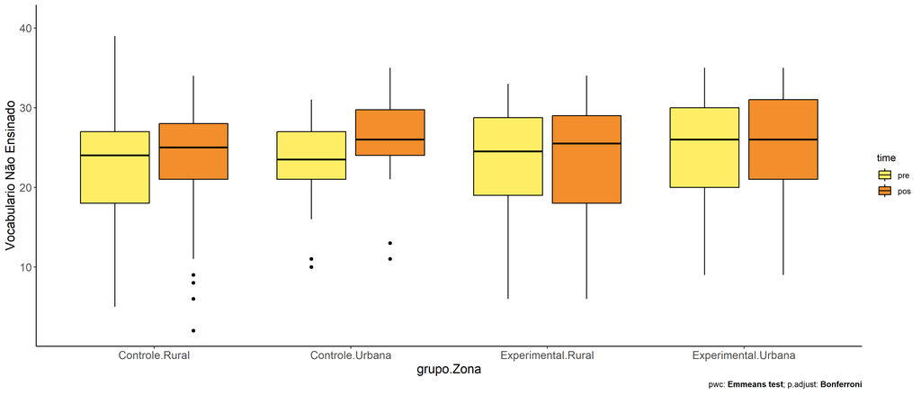

```r
plots[["grupo:Zona"]] + ggplot2::ylab("Vocabulario Não Ensinado")
```

### Checking linearity assumption

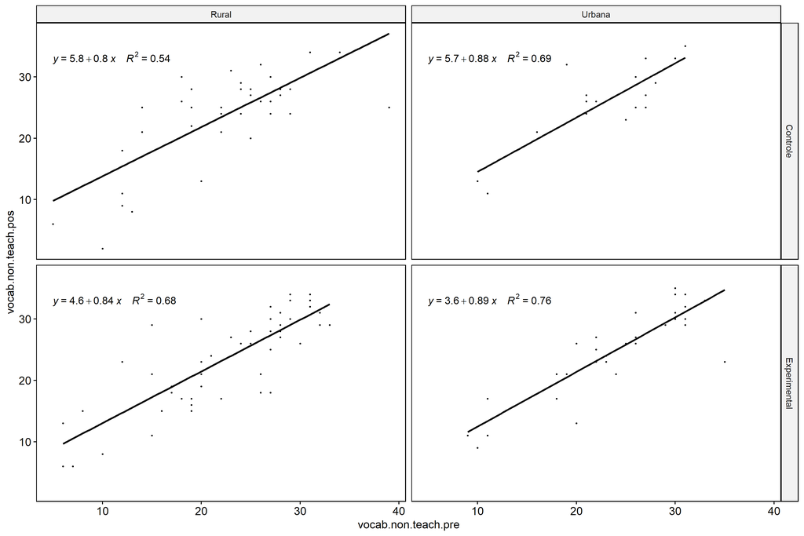

```r
ggscatter(wdat, x = "vocab.non.teach.pre", y = "vocab.non.teach.pos", size = 0.5,
          facet.by = c("grupo","Zona"), add = "reg.line")+
  stat_regline_equation(
    aes(label =  paste(..eq.label.., ..rr.label.., sep = "~~~~"))
  )
```

### Checking normality and homogeneity

```r
res <- augment(lm(vocab.non.teach.pos ~ vocab.non.teach.pre + grupo*Zona, data = wdat))
```

```r
shapiro_test(res$.resid)
```

```
## # A tibble: 1 × 3
##   variable   statistic p.value
##   <chr>          <dbl>   <dbl>
## 1 res$.resid     0.984  0.0888
```

```r
levene_test(res, .resid ~ grupo*Zona)
```

```
## # A tibble: 1 × 4
##     df1   df2 statistic      p
##   <int> <int>     <dbl>  <dbl>
## 1     3   138      2.65 0.0511
```

# ANCOVA and Pairwise for two factors **grupo:Cor.Raca**

## Without remove non-normal data

```r
pdat = remove_group_data(dat[!is.na(dat[["grupo"]]) & !is.na(dat[["Cor.Raca"]]),], "vocab.non.teach.pos", c("grupo","Cor.Raca"))
pdat.long <- rbind(pdat[,c("id","grupo","Cor.Raca")], pdat[,c("id","grupo","Cor.Raca")])
pdat.long[["time"]] <- c(rep("pre", nrow(pdat)), rep("pos", nrow(pdat)))
pdat.long[["time"]] <- factor(pdat.long[["time"]], c("pre","pos"))
pdat.long[["vocab.non.teach"]] <- c(pdat[["vocab.non.teach.pre"]], pdat[["vocab.non.teach.pos"]])

aov = anova_test(pdat, vocab.non.teach.pos ~ vocab.non.teach.pre + grupo*Cor.Raca)
laov[["grupo:Cor.Raca"]] <- get_anova_table(aov)
```

```r
pwcs <- list()
pwcs[["Cor.Raca"]] <- emmeans_test(
  group_by(pdat, grupo), vocab.non.teach.pos ~ Cor.Raca,
  covariate = vocab.non.teach.pre, p.adjust.method = "bonferroni")
pwcs[["grupo"]] <- emmeans_test(
  group_by(pdat, Cor.Raca), vocab.non.teach.pos ~ grupo,
  covariate = vocab.non.teach.pre, p.adjust.method = "bonferroni")

pwc <- plyr::rbind.fill(pwcs[["grupo"]], pwcs[["Cor.Raca"]])
pwc <- pwc[,c("grupo","Cor.Raca", colnames(pwc)[!colnames(pwc) %in% c("grupo","Cor.Raca")])]
```

```r
pwc.long <- emmeans_test(dplyr::group_by_at(pdat.long, c("grupo","Cor.Raca")),
                         vocab.non.teach ~ time,
                         p.adjust.method = "bonferroni")
lpwc[["grupo:Cor.Raca"]] <- plyr::rbind.fill(pwc, pwc.long)
```

```r
ds <- get.descriptives(pdat, "vocab.non.teach.pos", c("grupo","Cor.Raca"), covar = "vocab.non.teach.pre")
ds <- merge(ds[ds$variable != "vocab.non.teach.pre",],
            ds[ds$variable == "vocab.non.teach.pre", !colnames(ds) %in% c("variable")],
            by = c("grupo","Cor.Raca"), all.x = T, suffixes = c("", ".vocab.non.teach.pre"))
ds <- merge(get_emmeans(pwcs[["grupo"]]), ds, by = c("grupo","Cor.Raca"), suffixes = c(".emms", ""))
ds <- ds[,c("grupo","Cor.Raca","n","mean.vocab.non.teach.pre","se.vocab.non.teach.pre","mean","se","emmean","se.emms")]

colnames(ds) <- c("grupo","Cor.Raca", "N", paste0(c("M","SE")," (pre)"),
                  paste0(c("M","SE"), " (unadj)"), paste0(c("M", "SE"), " (adj)"))

lemms[["grupo:Cor.Raca"]] <- ds
```

## Computing ANCOVA and PairWise After removing non-normal data (OK)

```r
wdat = pdat

res = residuals(lm(vocab.non.teach.pos ~ vocab.non.teach.pre + grupo*Cor.Raca, data = wdat))
non.normal = getNonNormal(res, wdat$id, plimit = 0.05)

wdat = wdat[!wdat$id %in% non.normal,]

wdat.long <- rbind(wdat[,c("id","grupo","Cor.Raca")], wdat[,c("id","grupo","Cor.Raca")])
wdat.long[["time"]] <- c(rep("pre", nrow(wdat)), rep("pos", nrow(wdat)))
wdat.long[["time"]] <- factor(wdat.long[["time"]], c("pre","pos"))
wdat.long[["vocab.non.teach"]] <- c(wdat[["vocab.non.teach.pre"]], wdat[["vocab.non.teach.pos"]])


ldat[["grupo:Cor.Raca"]] = wdat

(non.normal)
```

```
## [1] "P1003" "P3654" "P1069" "P1006" "P996"  "P1056"
```

```r
aov = anova_test(wdat, vocab.non.teach.pos ~ vocab.non.teach.pre + grupo*Cor.Raca)
laov[["grupo:Cor.Raca"]] <- merge(get_anova_table(aov), laov[["grupo:Cor.Raca"]], by="Effect", suffixes = c("","'"))

(df = get_anova_table(aov))
```

```
## ANOVA Table (type II tests)
##
##                Effect DFn DFd       F        p p<.05   ges
## 1 vocab.non.teach.pre   1 100 169.014 3.24e-23     * 0.628
## 2               grupo   1 100   0.118 7.32e-01       0.001
## 3            Cor.Raca   1 100   2.307 1.32e-01       0.023
## 4      grupo:Cor.Raca   0 100      NA       NA  <NA>    NA
```

| Effect | DFn | DFd | F | p | p<.05 | ges |
| --- | --- | --- | --- | --- | --- | --- |
| vocab.non.teach.pre | 1 | 100 | 169.014 | 0.000 | * | 0.628 |
| grupo | 1 | 100 | 0.118 | 0.732 |  | 0.001 |
| Cor.Raca | 1 | 100 | 2.307 | 0.132 |  | 0.023 |
| grupo:Cor.Raca | 0 | 100 |  |  |  |  |

```r
pwcs <- list()
pwcs[["Cor.Raca"]] <- emmeans_test(
  group_by(wdat, grupo), vocab.non.teach.pos ~ Cor.Raca,
  covariate = vocab.non.teach.pre, p.adjust.method = "bonferroni")
pwcs[["grupo"]] <- emmeans_test(
  group_by(wdat, Cor.Raca), vocab.non.teach.pos ~ grupo,
  covariate = vocab.non.teach.pre, p.adjust.method = "bonferroni")

pwc <- plyr::rbind.fill(pwcs[["grupo"]], pwcs[["Cor.Raca"]])
pwc <- pwc[,c("grupo","Cor.Raca", colnames(pwc)[!colnames(pwc) %in% c("grupo","Cor.Raca")])]
```

| grupo | Cor.Raca | term | .y. | group1 | group2 | df | statistic | p | p.adj | p.adj.signif |
| --- | --- | --- | --- | --- | --- | --- | --- | --- | --- | --- |
|  | Branca | vocab.non.teach.pre*grupo | vocab.non.teach.pos | Controle | Experimental |  |  |  |  |  |
|  | Parda | vocab.non.teach.pre*grupo | vocab.non.teach.pos | Controle | Experimental | 100 | 0.343 | 0.732 | 0.732 | ns |
| Controle |  | vocab.non.teach.pre*Cor.Raca | vocab.non.teach.pos | Branca | Parda |  |  |  |  |  |
| Experimental |  | vocab.non.teach.pre*Cor.Raca | vocab.non.teach.pos | Branca | Parda | 100 | -1.519 | 0.132 | 0.132 | ns |

```r
pwc.long <- emmeans_test(dplyr::group_by_at(wdat.long, c("grupo","Cor.Raca")),
                         vocab.non.teach ~ time,
                         p.adjust.method = "bonferroni")
lpwc[["grupo:Cor.Raca"]] <- merge(plyr::rbind.fill(pwc, pwc.long), lpwc[["grupo:Cor.Raca"]], by=c("grupo","Cor.Raca","term",".y.","group1","group2"), suffixes = c("","'"))
```

| grupo | Cor.Raca | term | .y. | group1 | group2 | df | statistic | p | p.adj | p.adj.signif |
| --- | --- | --- | --- | --- | --- | --- | --- | --- | --- | --- |
| Controle | Branca | time | vocab.non.teach | pre | pos |  |  |  |  |  |
| Controle | Parda | time | vocab.non.teach | pre | pos | 202 | -1.165 | 0.245 | 0.245 | ns |
| Experimental | Branca | time | vocab.non.teach | pre | pos | 202 | 0.277 | 0.782 | 0.782 | ns |
| Experimental | Parda | time | vocab.non.teach | pre | pos | 202 | -1.199 | 0.232 | 0.232 | ns |

```r
ds <- get.descriptives(wdat, "vocab.non.teach.pos", c("grupo","Cor.Raca"), covar = "vocab.non.teach.pre")
ds <- merge(ds[ds$variable != "vocab.non.teach.pre",],
            ds[ds$variable == "vocab.non.teach.pre", !colnames(ds) %in% c("variable")],
            by = c("grupo","Cor.Raca"), all.x = T, suffixes = c("", ".vocab.non.teach.pre"))
ds <- merge(get_emmeans(pwcs[["grupo"]]), ds, by = c("grupo","Cor.Raca"), suffixes = c(".emms", ""))
ds <- ds[,c("grupo","Cor.Raca","n","mean.vocab.non.teach.pre","se.vocab.non.teach.pre","mean","se","emmean","se.emms")]

colnames(ds) <- c("grupo","Cor.Raca", "N", paste0(c("M","SE")," (pre)"),
                  paste0(c("M","SE"), " (unadj)"), paste0(c("M", "SE"), " (adj)"))

lemms[["grupo:Cor.Raca"]] <- merge(ds, lemms[["grupo:Cor.Raca"]], by=c("grupo","Cor.Raca"), suffixes = c("","'"))
```

| grupo | Cor.Raca | N | M (pre) | SE (pre) | M (unadj) | SE (unadj) | M (adj) | SE (adj) |
| --- | --- | --- | --- | --- | --- | --- | --- | --- |
| Controle | Parda | 33 | 21.939 | 1.201 | 24.121 | 1.351 | 24.638 | 0.822 |
| Experimental | Branca | 19 | 24.947 | 1.248 | 24.263 | 1.611 | 22.340 | 1.092 |
| Experimental | Parda | 52 | 22.115 | 1.173 | 23.904 | 1.092 | 24.278 | 0.654 |

### Plots for ancova

```r
plots <- twoWayAncovaPlots(
  wdat, "vocab.non.teach.pos", c("grupo","Cor.Raca"), aov, pwcs, addParam = c("mean_se"),
  font.label.size=10, step.increase=0.05, p.label="p.adj",
  subtitle = which(aov$Effect == "grupo:Cor.Raca"))
```

[figure not shown]

```r
if (!is.null(plots[["grupo"]]))
  plots[["grupo"]] + ggplot2::scale_color_manual(values = color[["Cor.Raca"]])
```

[figure not shown]

```r
if (!is.null(plots[["Cor.Raca"]]))
  plots[["Cor.Raca"]] + ggplot2::scale_color_manual(values = color[["grupo"]])
```

```r
plots <- twoWayAncovaBoxPlots(
  wdat, "vocab.non.teach.pos", c("grupo","Cor.Raca"), aov, pwcs, covar = "vocab.non.teach.pre",
  theme = "classic", color = color[["grupo:Cor.Raca"]],
  subtitle = which(aov$Effect == "grupo:Cor.Raca"))
```

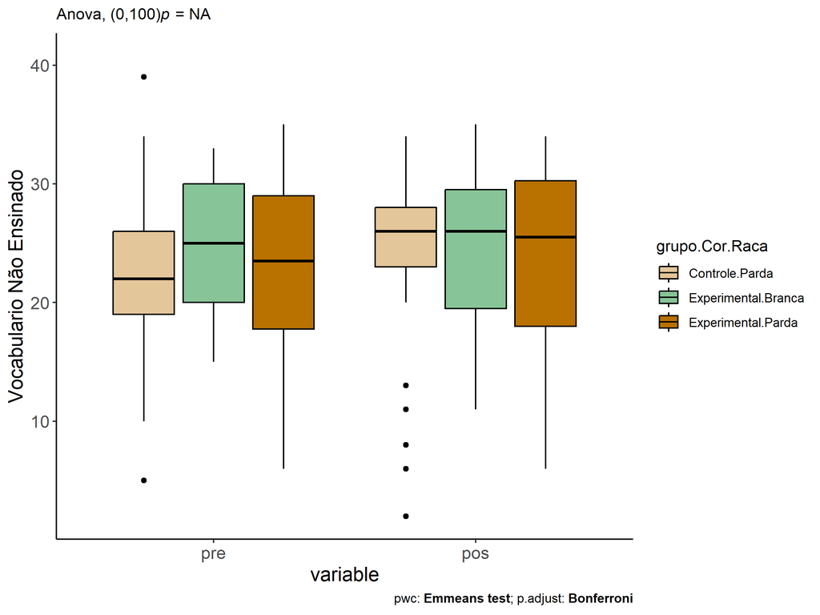

```r
plots[["grupo:Cor.Raca"]] + ggplot2::ylab("Vocabulario Não Ensinado") + ggplot2::scale_x_discrete(labels=c('pre', 'pos'))
```

```r
plots <- twoWayAncovaBoxPlots(
  wdat.long, "vocab.non.teach", c("grupo","Cor.Raca"), aov, pwc.long, pre.post = "time",
  theme = "classic", color = color$prepost)
```

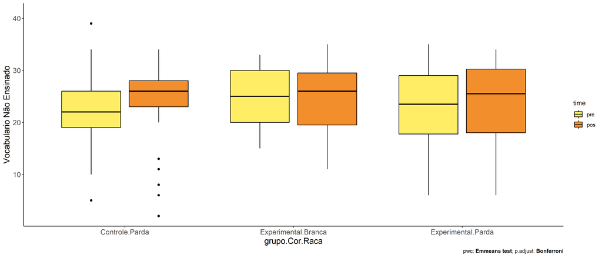

```r
plots[["grupo:Cor.Raca"]] + ggplot2::ylab("Vocabulario Não Ensinado")
```

### Checking linearity assumption

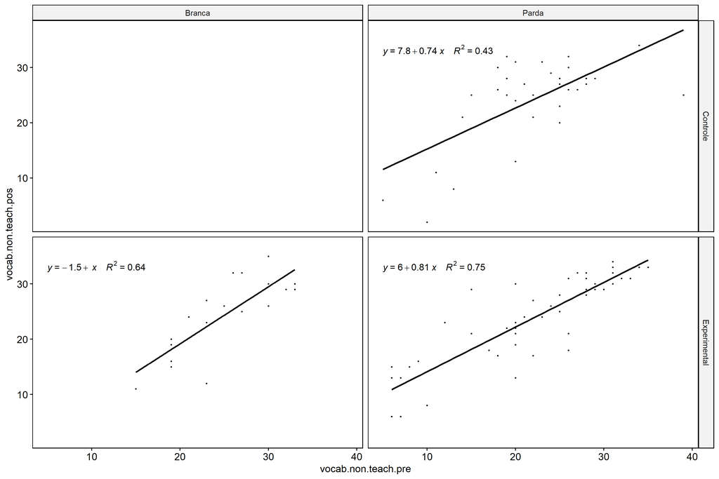

```r
ggscatter(wdat, x = "vocab.non.teach.pre", y = "vocab.non.teach.pos", size = 0.5,
          facet.by = c("grupo","Cor.Raca"), add = "reg.line")+
  stat_regline_equation(
    aes(label =  paste(..eq.label.., ..rr.label.., sep = "~~~~"))
  )
```

### Checking normality and homogeneity

```r
res <- augment(lm(vocab.non.teach.pos ~ vocab.non.teach.pre + grupo*Cor.Raca, data = wdat))
```

```r
shapiro_test(res$.resid)
```

```
## # A tibble: 1 × 3
##   variable   statistic p.value
##   <chr>          <dbl>   <dbl>
## 1 res$.resid     0.981   0.148
```

```r
levene_test(res, .resid ~ grupo*Cor.Raca)
```

```
## # A tibble: 1 × 4
##     df1   df2 statistic      p
##   <int> <int>     <dbl>  <dbl>
## 1     2   101      3.58 0.0314
```

# ANCOVA and Pairwise for two factors **grupo:vocab.non.teach.quintile**

## Without remove non-normal data

```r
pdat = remove_group_data(dat[!is.na(dat[["grupo"]]) & !is.na(dat[["vocab.non.teach.quintile"]]),], "vocab.non.teach.pos", c("grupo","vocab.non.teach.quintile"))

pdat.long <- rbind(pdat[,c("id","grupo","vocab.non.teach.quintile")], pdat[,c("id","grupo","vocab.non.teach.quintile")])
pdat.long[["time"]] <- c(rep("pre", nrow(pdat)), rep("pos", nrow(pdat)))
pdat.long[["time"]] <- factor(pdat.long[["time"]], c("pre","pos"))
pdat.long[["vocab.non.teach"]] <- c(pdat[["vocab.non.teach.pre"]], pdat[["vocab.non.teach.pos"]])

aov = anova_test(pdat, vocab.non.teach.pos ~ vocab.non.teach.pre + grupo*vocab.non.teach.quintile)
laov[["grupo:vocab.non.teach.quintile"]] <- get_anova_table(aov)
```

```r
pwcs <- list()
pwcs[["vocab.non.teach.quintile"]] <- emmeans_test(
  group_by(pdat, grupo), vocab.non.teach.pos ~ vocab.non.teach.quintile,
  covariate = vocab.non.teach.pre, p.adjust.method = "bonferroni")
pwcs[["grupo"]] <- emmeans_test(
  group_by(pdat, vocab.non.teach.quintile), vocab.non.teach.pos ~ grupo,
  covariate = vocab.non.teach.pre, p.adjust.method = "bonferroni")

pwc <- plyr::rbind.fill(pwcs[["grupo"]], pwcs[["vocab.non.teach.quintile"]])
pwc <- pwc[,c("grupo","vocab.non.teach.quintile", colnames(pwc)[!colnames(pwc) %in% c("grupo","vocab.non.teach.quintile")])]
```

```r
pwc.long <- emmeans_test(dplyr::group_by_at(pdat.long, c("grupo","vocab.non.teach.quintile")),
                         vocab.non.teach ~ time,
                         p.adjust.method = "bonferroni")
lpwc[["grupo:vocab.non.teach.quintile"]] <- plyr::rbind.fill(pwc, pwc.long)
```

```r
ds <- get.descriptives(pdat, "vocab.non.teach.pos", c("grupo","vocab.non.teach.quintile"), covar = "vocab.non.teach.pre")
ds <- merge(ds[ds$variable != "vocab.non.teach.pre",],
            ds[ds$variable == "vocab.non.teach.pre", !colnames(ds) %in% c("variable")],
            by = c("grupo","vocab.non.teach.quintile"), all.x = T, suffixes = c("", ".vocab.non.teach.pre"))
ds <- merge(get_emmeans(pwcs[["grupo"]]), ds, by = c("grupo","vocab.non.teach.quintile"), suffixes = c(".emms", ""))
ds <- ds[,c("grupo","vocab.non.teach.quintile","n","mean.vocab.non.teach.pre","se.vocab.non.teach.pre","mean","se","emmean","se.emms")]

colnames(ds) <- c("grupo","vocab.non.teach.quintile", "N", paste0(c("M","SE")," (pre)"),
                  paste0(c("M","SE"), " (unadj)"), paste0(c("M", "SE"), " (adj)"))

lemms[["grupo:vocab.non.teach.quintile"]] <- ds
```

## Computing ANCOVA and PairWise After removing non-normal data (OK)

```r
wdat = pdat

res = residuals(lm(vocab.non.teach.pos ~ vocab.non.teach.pre + grupo*vocab.non.teach.quintile, data = wdat))
non.normal = getNonNormal(res, wdat$id, plimit = 0.05)

wdat = wdat[!wdat$id %in% non.normal,]

wdat.long <- rbind(wdat[,c("id","grupo","vocab.non.teach.quintile")], wdat[,c("id","grupo","vocab.non.teach.quintile")])
wdat.long[["time"]] <- c(rep("pre", nrow(wdat)), rep("pos", nrow(wdat)))
wdat.long[["time"]] <- factor(wdat.long[["time"]], c("pre","pos"))
wdat.long[["vocab.non.teach"]] <- c(wdat[["vocab.non.teach.pre"]], wdat[["vocab.non.teach.pos"]])


ldat[["grupo:vocab.non.teach.quintile"]] = wdat

(non.normal)
```

```
##  [1] "P1003" "P2207" "P2245" "P1069" "P1006" "P2251" "P1056" "P2232" "P2192" "P996"  "P3654" "P2206" "P2219"
## [14] "P2082" "P2223" "P1009" "P3658" "P2069"
```

```r
aov = anova_test(wdat, vocab.non.teach.pos ~ vocab.non.teach.pre + grupo*vocab.non.teach.quintile)
laov[["grupo:vocab.non.teach.quintile"]] <- merge(get_anova_table(aov), laov[["grupo:vocab.non.teach.quintile"]], by="Effect", suffixes = c("","'"))

(df = get_anova_table(aov))
```

```
## ANOVA Table (type II tests)
##
##                           Effect DFn DFd      F        p p<.05   ges
## 1            vocab.non.teach.pre   1 252 16.176 7.63e-05     * 0.060
## 2                          grupo   1 252  2.339 1.27e-01       0.009
## 3       vocab.non.teach.quintile   4 252  1.498 2.03e-01       0.023
## 4 grupo:vocab.non.teach.quintile   4 252  8.602 1.60e-06     * 0.120
```

| Effect | DFn | DFd | F | p | p<.05 | ges |
| --- | --- | --- | --- | --- | --- | --- |
| vocab.non.teach.pre | 1 | 252 | 16.176 | 0.000 | * | 0.060 |
| grupo | 1 | 252 | 2.339 | 0.127 |  | 0.009 |
| vocab.non.teach.quintile | 4 | 252 | 1.498 | 0.203 |  | 0.023 |
| grupo:vocab.non.teach.quintile | 4 | 252 | 8.602 | 0.000 | * | 0.120 |

```r
pwcs <- list()
pwcs[["vocab.non.teach.quintile"]] <- emmeans_test(
  group_by(wdat, grupo), vocab.non.teach.pos ~ vocab.non.teach.quintile,
  covariate = vocab.non.teach.pre, p.adjust.method = "bonferroni")
pwcs[["grupo"]] <- emmeans_test(
  group_by(wdat, vocab.non.teach.quintile), vocab.non.teach.pos ~ grupo,
  covariate = vocab.non.teach.pre, p.adjust.method = "bonferroni")

pwc <- plyr::rbind.fill(pwcs[["grupo"]], pwcs[["vocab.non.teach.quintile"]])
pwc <- pwc[,c("grupo","vocab.non.teach.quintile", colnames(pwc)[!colnames(pwc) %in% c("grupo","vocab.non.teach.quintile")])]
```

| grupo | vocab.non.teach.quintile | term | .y. | group1 | group2 | df | statistic | p | p.adj | p.adj.signif |
| --- | --- | --- | --- | --- | --- | --- | --- | --- | --- | --- |
|  | 1st quintile | vocab.non.teach.pre*grupo | vocab.non.teach.pos | Controle | Experimental | 252 | -2.618 | 0.009 | 0.009 | ** |
|  | 2nd quintile | vocab.non.teach.pre*grupo | vocab.non.teach.pos | Controle | Experimental | 252 | 4.881 | 0.000 | 0.000 | **** |
|  | 3rd quintile | vocab.non.teach.pre*grupo | vocab.non.teach.pos | Controle | Experimental | 252 | 2.088 | 0.038 | 0.038 | * |
|  | 4th quintile | vocab.non.teach.pre*grupo | vocab.non.teach.pos | Controle | Experimental | 252 | -1.147 | 0.253 | 0.253 | ns |
|  | 5th quintile | vocab.non.teach.pre*grupo | vocab.non.teach.pos | Controle | Experimental | 252 | 0.400 | 0.690 | 0.690 | ns |
| Controle |  | vocab.non.teach.pre*vocab.non.teach.quintile | vocab.non.teach.pos | 1st quintile | 2nd quintile | 252 | -5.352 | 0.000 | 0.000 | **** |
| Controle |  | vocab.non.teach.pre*vocab.non.teach.quintile | vocab.non.teach.pos | 1st quintile | 3rd quintile | 252 | -3.506 | 0.001 | 0.005 | ** |
| Controle |  | vocab.non.teach.pre*vocab.non.teach.quintile | vocab.non.teach.pos | 1st quintile | 4th quintile | 252 | -2.535 | 0.012 | 0.118 | ns |
| Controle |  | vocab.non.teach.pre*vocab.non.teach.quintile | vocab.non.teach.pos | 1st quintile | 5th quintile | 252 | -2.563 | 0.011 | 0.110 | ns |
| Controle |  | vocab.non.teach.pre*vocab.non.teach.quintile | vocab.non.teach.pos | 2nd quintile | 3rd quintile | 252 | 1.388 | 0.166 | 1.000 | ns |
| Controle |  | vocab.non.teach.pre*vocab.non.teach.quintile | vocab.non.teach.pos | 2nd quintile | 4th quintile | 252 | 1.566 | 0.119 | 1.000 | ns |
| Controle |  | vocab.non.teach.pre*vocab.non.teach.quintile | vocab.non.teach.pos | 2nd quintile | 5th quintile | 252 | 0.304 | 0.761 | 1.000 | ns |
| Controle |  | vocab.non.teach.pre*vocab.non.teach.quintile | vocab.non.teach.pos | 3rd quintile | 4th quintile | 252 | 0.619 | 0.536 | 1.000 | ns |
| Controle |  | vocab.non.teach.pre*vocab.non.teach.quintile | vocab.non.teach.pos | 3rd quintile | 5th quintile | 252 | -0.668 | 0.505 | 1.000 | ns |
| Controle |  | vocab.non.teach.pre*vocab.non.teach.quintile | vocab.non.teach.pos | 4th quintile | 5th quintile | 252 | -1.362 | 0.174 | 1.000 | ns |
| Experimental |  | vocab.non.teach.pre*vocab.non.teach.quintile | vocab.non.teach.pos | 1st quintile | 2nd quintile | 252 | 0.251 | 0.802 | 1.000 | ns |
| Experimental |  | vocab.non.teach.pre*vocab.non.teach.quintile | vocab.non.teach.pos | 1st quintile | 3rd quintile | 252 | -0.776 | 0.438 | 1.000 | ns |
| Experimental |  | vocab.non.teach.pre*vocab.non.teach.quintile | vocab.non.teach.pos | 1st quintile | 4th quintile | 252 | -1.500 | 0.135 | 1.000 | ns |
| Experimental |  | vocab.non.teach.pre*vocab.non.teach.quintile | vocab.non.teach.pos | 1st quintile | 5th quintile | 252 | -1.370 | 0.172 | 1.000 | ns |
| Experimental |  | vocab.non.teach.pre*vocab.non.teach.quintile | vocab.non.teach.pos | 2nd quintile | 3rd quintile | 252 | -1.757 | 0.080 | 0.802 | ns |
| Experimental |  | vocab.non.teach.pre*vocab.non.teach.quintile | vocab.non.teach.pos | 2nd quintile | 4th quintile | 252 | -2.707 | 0.007 | 0.073 | ns |
| Experimental |  | vocab.non.teach.pre*vocab.non.teach.quintile | vocab.non.teach.pos | 2nd quintile | 5th quintile | 252 | -2.212 | 0.028 | 0.279 | ns |
| Experimental |  | vocab.non.teach.pre*vocab.non.teach.quintile | vocab.non.teach.pos | 3rd quintile | 4th quintile | 252 | -2.184 | 0.030 | 0.299 | ns |
| Experimental |  | vocab.non.teach.pre*vocab.non.teach.quintile | vocab.non.teach.pos | 3rd quintile | 5th quintile | 252 | -1.794 | 0.074 | 0.741 | ns |
| Experimental |  | vocab.non.teach.pre*vocab.non.teach.quintile | vocab.non.teach.pos | 4th quintile | 5th quintile | 252 | -0.489 | 0.625 | 1.000 | ns |

```r
pwc.long <- emmeans_test(dplyr::group_by_at(wdat.long, c("grupo","vocab.non.teach.quintile")),
                         vocab.non.teach ~ time,
                         p.adjust.method = "bonferroni")
lpwc[["grupo:vocab.non.teach.quintile"]] <- merge(plyr::rbind.fill(pwc, pwc.long), lpwc[["grupo:vocab.non.teach.quintile"]], by=c("grupo","vocab.non.teach.quintile","term",".y.","group1","group2"), suffixes = c("","'"))
```

| grupo | vocab.non.teach.quintile | term | .y. | group1 | group2 | df | statistic | p | p.adj | p.adj.signif |
| --- | --- | --- | --- | --- | --- | --- | --- | --- | --- | --- |
| Controle | 1st quintile | time | vocab.non.teach | pre | pos | 506 | -0.180 | 0.858 | 0.858 | ns |
| Controle | 2nd quintile | time | vocab.non.teach | pre | pos | 506 | -5.654 | 0.000 | 0.000 | **** |
| Controle | 3rd quintile | time | vocab.non.teach | pre | pos | 506 | -2.866 | 0.004 | 0.004 | ** |
| Controle | 4th quintile | time | vocab.non.teach | pre | pos | 506 | 0.043 | 0.966 | 0.966 | ns |
| Controle | 5th quintile | time | vocab.non.teach | pre | pos | 506 | 0.194 | 0.846 | 0.846 | ns |
| Experimental | 1st quintile | time | vocab.non.teach | pre | pos | 506 | -4.471 | 0.000 | 0.000 | **** |
| Experimental | 2nd quintile | time | vocab.non.teach | pre | pos | 506 | -0.859 | 0.391 | 0.391 | ns |
| Experimental | 3rd quintile | time | vocab.non.teach | pre | pos | 506 | -1.090 | 0.276 | 0.276 | ns |
| Experimental | 4th quintile | time | vocab.non.teach | pre | pos | 506 | -1.552 | 0.121 | 0.121 | ns |
| Experimental | 5th quintile | time | vocab.non.teach | pre | pos | 506 | 0.795 | 0.427 | 0.427 | ns |

```r
ds <- get.descriptives(wdat, "vocab.non.teach.pos", c("grupo","vocab.non.teach.quintile"), covar = "vocab.non.teach.pre")
ds <- merge(ds[ds$variable != "vocab.non.teach.pre",],
            ds[ds$variable == "vocab.non.teach.pre", !colnames(ds) %in% c("variable")],
            by = c("grupo","vocab.non.teach.quintile"), all.x = T, suffixes = c("", ".vocab.non.teach.pre"))
ds <- merge(get_emmeans(pwcs[["grupo"]]), ds, by = c("grupo","vocab.non.teach.quintile"), suffixes = c(".emms", ""))
ds <- ds[,c("grupo","vocab.non.teach.quintile","n","mean.vocab.non.teach.pre","se.vocab.non.teach.pre","mean","se","emmean","se.emms")]

colnames(ds) <- c("grupo","vocab.non.teach.quintile", "N", paste0(c("M","SE")," (pre)"),
                  paste0(c("M","SE"), " (unadj)"), paste0(c("M", "SE"), " (adj)"))

lemms[["grupo:vocab.non.teach.quintile"]] <- merge(ds, lemms[["grupo:vocab.non.teach.quintile"]], by=c("grupo","vocab.non.teach.quintile"), suffixes = c("","'"))
```

| grupo | vocab.non.teach.quintile | N | M (pre) | SE (pre) | M (unadj) | SE (unadj) | M (adj) | SE (adj) |
| --- | --- | --- | --- | --- | --- | --- | --- | --- |
| Controle | 1st quintile | 14 | 10.357 | 0.700 | 10.571 | 1.300 | 17.770 | 2.082 |
| Controle | 2nd quintile | 13 | 17.308 | 0.524 | 24.308 | 1.575 | 27.534 | 1.365 |
| Controle | 3rd quintile | 22 | 22.227 | 0.286 | 24.955 | 0.763 | 25.370 | 0.855 |
| Controle | 4th quintile | 27 | 26.778 | 0.247 | 26.741 | 0.687 | 24.556 | 0.940 |
| Controle | 5th quintile | 12 | 32.333 | 0.772 | 32.083 | 1.026 | 26.724 | 1.760 |
| Experimental | 1st quintile | 19 | 8.842 | 0.589 | 13.421 | 1.415 | 21.485 | 2.203 |
| Experimental | 2nd quintile | 30 | 16.933 | 0.307 | 17.633 | 0.826 | 21.074 | 1.123 |
| Experimental | 3rd quintile | 38 | 21.526 | 0.241 | 22.316 | 0.727 | 23.132 | 0.677 |
| Experimental | 4th quintile | 46 | 26.891 | 0.209 | 27.913 | 0.516 | 25.663 | 0.811 |
| Experimental | 5th quintile | 42 | 31.810 | 0.267 | 31.262 | 0.381 | 26.202 | 1.400 |

### Plots for ancova

```r
plots <- twoWayAncovaPlots(
  wdat, "vocab.non.teach.pos", c("grupo","vocab.non.teach.quintile"), aov, pwcs, addParam = c("mean_se"),
  font.label.size=10, step.increase=0.05, p.label="p.adj",
  subtitle = which(aov$Effect == "grupo:vocab.non.teach.quintile"))
```

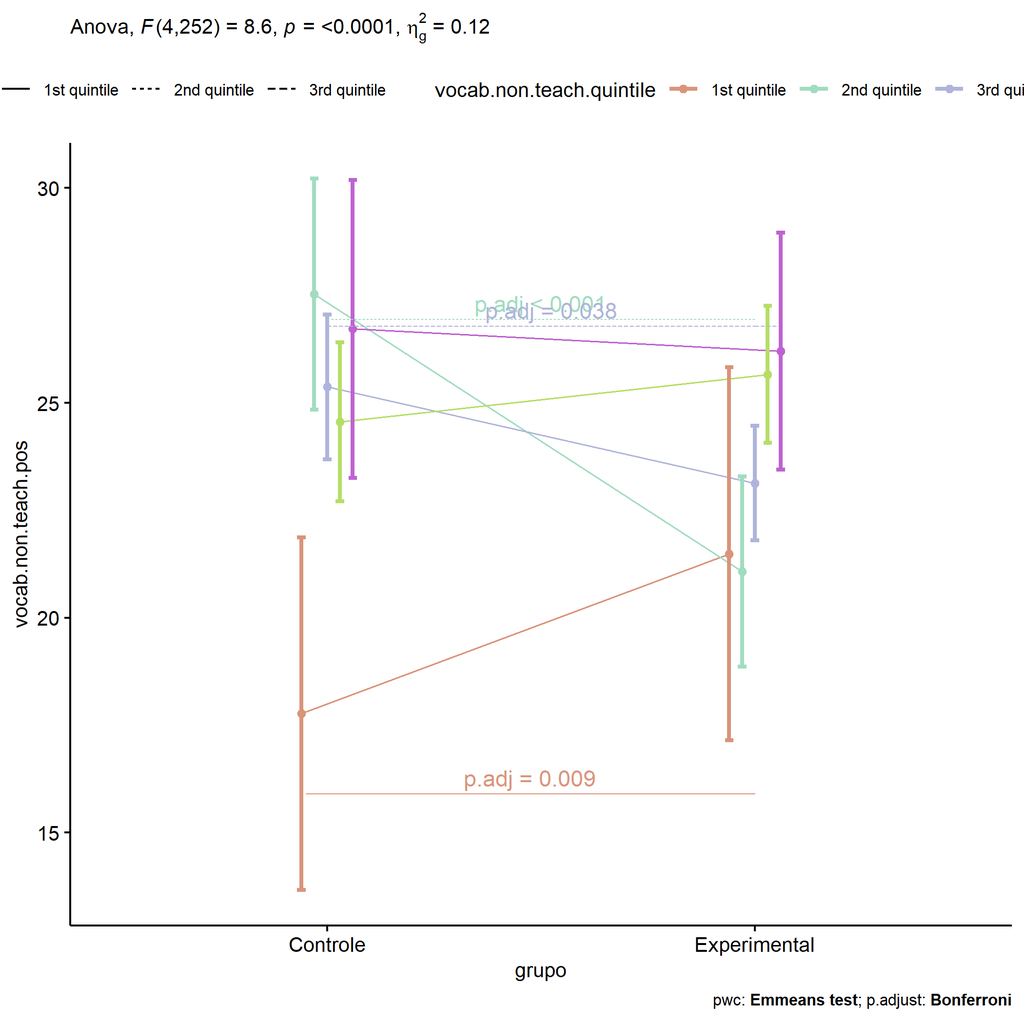

```r
if (!is.null(plots[["grupo"]]))
  plots[["grupo"]] + ggplot2::scale_color_manual(values = color[["vocab.non.teach.quintile"]])
```

```
## Warning: `position_dodge()` requires non-overlapping x intervals
```

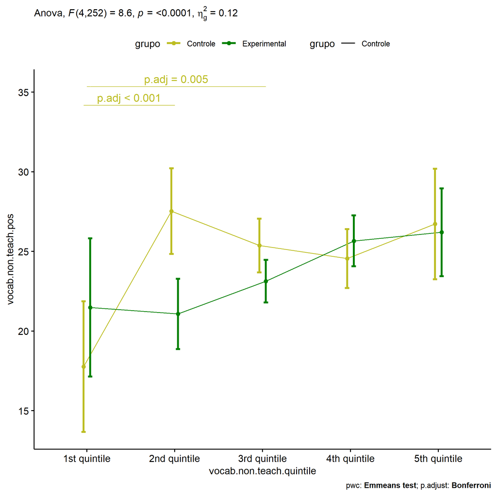

```r
if (!is.null(plots[["vocab.non.teach.quintile"]]))
  plots[["vocab.non.teach.quintile"]] + ggplot2::scale_color_manual(values = color[["grupo"]])
```

```r
plots <- twoWayAncovaBoxPlots(
  wdat, "vocab.non.teach.pos", c("grupo","vocab.non.teach.quintile"), aov, pwcs, covar = "vocab.non.teach.pre",
  theme = "classic", color = color[["grupo:vocab.non.teach.quintile"]],
  subtitle = which(aov$Effect == "grupo:vocab.non.teach.quintile"))
```

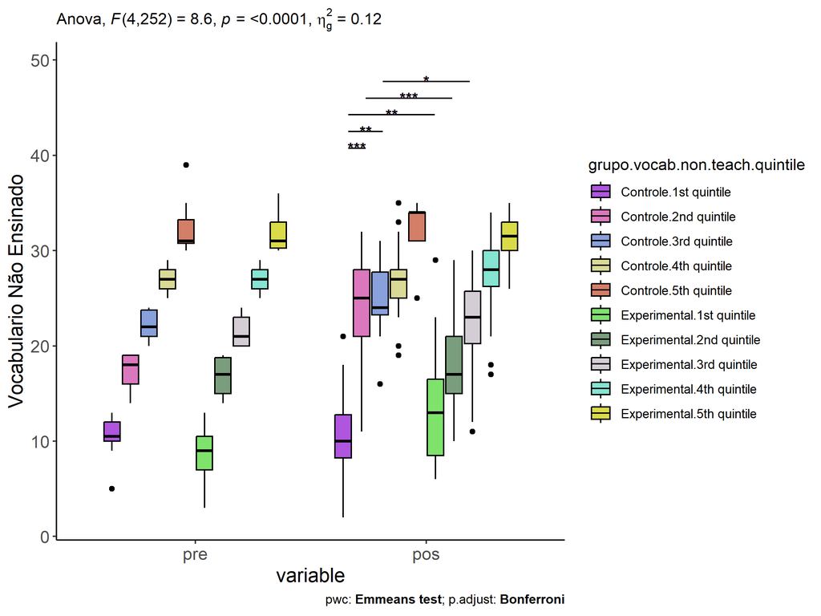

```r
plots[["grupo:vocab.non.teach.quintile"]] + ggplot2::ylab("Vocabulario Não Ensinado") + ggplot2::scale_x_discrete(labels=c('pre', 'pos'))
```

```r
plots <- twoWayAncovaBoxPlots(
  wdat.long, "vocab.non.teach", c("grupo","vocab.non.teach.quintile"), aov, pwc.long, pre.post = "time",
  theme = "classic", color = color$prepost)
```

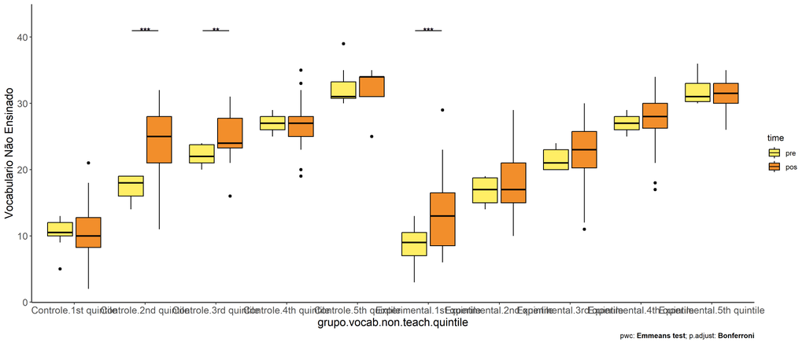

```r
plots[["grupo:vocab.non.teach.quintile"]] + ggplot2::ylab("Vocabulario Não Ensinado")
```

### Checking linearity assumption

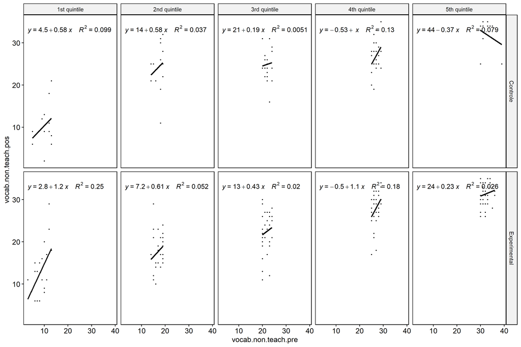

```r
ggscatter(wdat, x = "vocab.non.teach.pre", y = "vocab.non.teach.pos", size = 0.5,
          facet.by = c("grupo","vocab.non.teach.quintile"), add = "reg.line")+
  stat_regline_equation(
    aes(label =  paste(..eq.label.., ..rr.label.., sep = "~~~~"))
  )
```

### Checking normality and homogeneity

```r
res <- augment(lm(vocab.non.teach.pos ~ vocab.non.teach.pre + grupo*vocab.non.teach.quintile, data = wdat))
```

```r
shapiro_test(res$.resid)
```

```
## # A tibble: 1 × 3
##   variable   statistic p.value
##   <chr>          <dbl>   <dbl>
## 1 res$.resid     0.981 0.00143
```

```r
levene_test(res, .resid ~ grupo*vocab.non.teach.quintile)
```

```
## # A tibble: 1 × 4
##     df1   df2 statistic      p
##   <int> <int>     <dbl>  <dbl>
## 1     9   253      2.22 0.0211
```

# Summary of Results

## Descriptive Statistics

```r
df <- get.descriptives(ldat[["grupo"]], c(dv.pre, dv.pos), c("grupo"),
                       include.global = T, symmetry.test = T, normality.test = F)
df <- plyr::rbind.fill(
  df, do.call(plyr::rbind.fill, lapply(lfatores2, FUN = function(f) {
    if (nrow(dat) > 0 && sum(!is.na(unique(dat[[f]]))) > 1)
      get.descriptives(ldat[[paste0("grupo:",f)]], c(dv.pre,dv.pos), c("grupo", f),
                       symmetry.test = T, normality.test = F)
    }))
)
(df <- df[,c(fatores1[fatores1 %in% colnames(df)],"variable",
             colnames(df)[!colnames(df) %in% c(fatores1,"variable")])])
```

```
##           grupo Sexo   Zona Cor.Raca vocab.non.teach.quintile            variable   n   mean median min max
## 1      Controle <NA>   <NA>     <NA>                     <NA> vocab.non.teach.pre  87 22.276   24.0   5  35
## 2  Experimental <NA>   <NA>     <NA>                     <NA> vocab.non.teach.pre 171 23.339   25.0   3  36
## 3          <NA> <NA>   <NA>     <NA>                     <NA> vocab.non.teach.pre 258 22.981   24.0   3  36
## 4      Controle <NA>   <NA>     <NA>                     <NA> vocab.non.teach.pos  87 23.989   25.0   6  35
## 5  Experimental <NA>   <NA>     <NA>                     <NA> vocab.non.teach.pos 171 24.333   26.0   6  35
## 6          <NA> <NA>   <NA>     <NA>                     <NA> vocab.non.teach.pos 258 24.217   26.0   6  35
## 7      Controle    F   <NA>     <NA>                     <NA> vocab.non.teach.pre  45 23.133   24.0   5  35
## 8      Controle    M   <NA>     <NA>                     <NA> vocab.non.teach.pre  40 21.450   21.0  10  34
## 9  Experimental    F   <NA>     <NA>                     <NA> vocab.non.teach.pre  86 24.733   26.0   3  36
## 10 Experimental    M   <NA>     <NA>                     <NA> vocab.non.teach.pre  79 22.747   24.0   6  36
## 11     Controle    F   <NA>     <NA>                     <NA> vocab.non.teach.pos  45 25.378   27.0   6  35
## 12     Controle    M   <NA>     <NA>                     <NA> vocab.non.teach.pos  40 22.400   24.0   6  35
## 13 Experimental    F   <NA>     <NA>                     <NA> vocab.non.teach.pos  86 25.767   27.0   6  35
## 14 Experimental    M   <NA>     <NA>                     <NA> vocab.non.teach.pos  79 23.747   25.0   6  35
```

[output cut: 83 more lines]

| grupo | Sexo | Zona | Cor.Raca | vocab.non.teach.quintile | variable | n | mean | median | min | max | sd | se | ci | iqr | symmetry | skewness | kurtosis |
| --- | --- | --- | --- | --- | --- | --- | --- | --- | --- | --- | --- | --- | --- | --- | --- | --- | --- |
| Controle |  |  |  |  | vocab.non.teach.pre | 87 | 22.276 | 24.0 | 5 | 35 | 6.792 | 0.728 | 1.448 | 8.50 | NO | -0.536 | -0.360 |
| Experimental |  |  |  |  | vocab.non.teach.pre | 171 | 23.339 | 25.0 | 3 | 36 | 7.377 | 0.564 | 1.114 | 10.00 | NO | -0.576 | -0.350 |
|  |  |  |  |  | vocab.non.teach.pre | 258 | 22.981 | 24.0 | 3 | 36 | 7.190 | 0.448 | 0.881 | 9.00 | NO | -0.549 | -0.339 |
| Controle |  |  |  |  | vocab.non.teach.pos | 87 | 23.989 | 25.0 | 6 | 35 | 7.390 | 0.792 | 1.575 | 7.50 | NO | -0.752 | -0.157 |
| Experimental |  |  |  |  | vocab.non.teach.pos | 171 | 24.333 | 26.0 | 6 | 35 | 7.178 | 0.549 | 1.084 | 10.00 | NO | -0.653 | -0.447 |
|  |  |  |  |  | vocab.non.teach.pos | 258 | 24.217 | 26.0 | 6 | 35 | 7.237 | 0.451 | 0.887 | 9.75 | NO | -0.694 | -0.311 |
| Controle | F |  |  |  | vocab.non.teach.pre | 45 | 23.133 | 24.0 | 5 | 35 | 6.737 | 1.004 | 2.024 | 6.00 | NO | -1.034 | 0.827 |
| Controle | M |  |  |  | vocab.non.teach.pre | 40 | 21.450 | 21.0 | 10 | 34 | 6.790 | 1.074 | 2.171 | 10.25 | YES | -0.006 | -1.173 |
| Experimental | F |  |  |  | vocab.non.teach.pre | 86 | 24.733 | 26.0 | 3 | 36 | 7.309 | 0.788 | 1.567 | 10.75 | NO | -0.761 | -0.040 |
| Experimental | M |  |  |  | vocab.non.teach.pre | 79 | 22.747 | 24.0 | 6 | 36 | 6.938 | 0.781 | 1.554 | 9.00 | NO | -0.637 | -0.117 |
| Controle | F |  |  |  | vocab.non.teach.pos | 45 | 25.378 | 27.0 | 6 | 35 | 6.863 | 1.023 | 2.062 | 5.00 | NO | -1.043 | 0.649 |
| Controle | M |  |  |  | vocab.non.teach.pos | 40 | 22.400 | 24.0 | 6 | 35 | 7.665 | 1.212 | 2.452 | 6.50 | YES | -0.451 | -0.681 |
| Experimental | F |  |  |  | vocab.non.teach.pos | 86 | 25.767 | 27.0 | 6 | 35 | 6.595 | 0.711 | 1.414 | 10.00 | NO | -0.719 | -0.202 |
| Experimental | M |  |  |  | vocab.non.teach.pos | 79 | 23.747 | 25.0 | 6 | 35 | 6.740 | 0.758 | 1.510 | 10.00 | NO | -0.542 | -0.593 |
| Controle |  | Rural |  |  | vocab.non.teach.pre | 37 | 22.054 | 24.0 | 5 | 39 | 7.149 | 1.175 | 2.384 | 9.00 | YES | -0.207 | -0.193 |
| Controle |  | Urbana |  |  | vocab.non.teach.pre | 18 | 22.722 | 23.5 | 10 | 31 | 5.949 | 1.402 | 2.958 | 6.00 | NO | -0.694 | -0.476 |
| Experimental |  | Rural |  |  | vocab.non.teach.pre | 54 | 22.685 | 24.5 | 6 | 33 | 7.239 | 0.985 | 1.976 | 9.75 | NO | -0.681 | -0.438 |
| Experimental |  | Urbana |  |  | vocab.non.teach.pre | 33 | 24.424 | 26.0 | 9 | 35 | 7.093 | 1.235 | 2.515 | 10.00 | NO | -0.658 | -0.522 |
| Controle |  | Rural |  |  | vocab.non.teach.pos | 37 | 23.459 | 25.0 | 2 | 34 | 7.802 | 1.283 | 2.601 | 7.00 | NO | -1.157 | 0.534 |
| Controle |  | Urbana |  |  | vocab.non.teach.pos | 18 | 25.778 | 26.0 | 11 | 35 | 6.320 | 1.490 | 3.143 | 5.75 | NO | -0.784 | 0.118 |
| Experimental |  | Rural |  |  | vocab.non.teach.pos | 54 | 23.704 | 25.5 | 6 | 34 | 7.363 | 1.002 | 2.010 | 11.00 | NO | -0.634 | -0.480 |
| Experimental |  | Urbana |  |  | vocab.non.teach.pos | 33 | 25.303 | 26.0 | 9 | 35 | 7.218 | 1.256 | 2.559 | 10.00 | NO | -0.714 | -0.502 |
| Controle |  |  | Parda |  | vocab.non.teach.pre | 33 | 21.939 | 22.0 | 5 | 39 | 6.901 | 1.201 | 2.447 | 7.00 | YES | -0.133 | 0.269 |
| Experimental |  |  | Branca |  | vocab.non.teach.pre | 19 | 24.947 | 25.0 | 15 | 33 | 5.441 | 1.248 | 2.623 | 10.00 | YES | -0.036 | -1.322 |
| Experimental |  |  | Parda |  | vocab.non.teach.pre | 52 | 22.115 | 23.5 | 6 | 35 | 8.461 | 1.173 | 2.356 | 11.25 | NO | -0.540 | -0.890 |
| Controle |  |  | Parda |  | vocab.non.teach.pos | 33 | 24.121 | 26.0 | 2 | 34 | 7.761 | 1.351 | 2.752 | 5.00 | NO | -1.378 | 1.060 |
| Experimental |  |  | Branca |  | vocab.non.teach.pos | 19 | 24.263 | 26.0 | 11 | 35 | 7.023 | 1.611 | 3.385 | 10.00 | YES | -0.452 | -1.044 |
| Experimental |  |  | Parda |  | vocab.non.teach.pos | 52 | 23.904 | 25.5 | 6 | 34 | 7.875 | 1.092 | 2.192 | 12.25 | NO | -0.682 | -0.627 |
| Controle |  |  |  | 1st quintile | vocab.non.teach.pre | 14 | 10.357 | 10.5 | 5 | 13 | 2.620 | 0.700 | 1.513 | 2.00 | NO | -0.958 | -0.241 |
| Controle |  |  |  | 2nd quintile | vocab.non.teach.pre | 13 | 17.308 | 18.0 | 14 | 19 | 1.888 | 0.524 | 1.141 | 3.00 | NO | -0.753 | -1.155 |
| Controle |  |  |  | 3rd quintile | vocab.non.teach.pre | 22 | 22.227 | 22.0 | 20 | 24 | 1.343 | 0.286 | 0.595 | 2.75 | YES | 0.055 | -1.315 |
| Controle |  |  |  | 4th quintile | vocab.non.teach.pre | 27 | 26.778 | 27.0 | 25 | 29 | 1.281 | 0.247 | 0.507 | 2.00 | YES | 0.189 | -1.118 |
| Controle |  |  |  | 5th quintile | vocab.non.teach.pre | 12 | 32.333 | 31.0 | 30 | 39 | 2.674 | 0.772 | 1.699 | 2.50 | NO | 1.189 | 0.480 |
| Experimental |  |  |  | 1st quintile | vocab.non.teach.pre | 19 | 8.842 | 9.0 | 3 | 13 | 2.566 | 0.589 | 1.237 | 3.50 | YES | -0.376 | -0.654 |
| Experimental |  |  |  | 2nd quintile | vocab.non.teach.pre | 30 | 16.933 | 17.0 | 14 | 19 | 1.680 | 0.307 | 0.627 | 3.75 | YES | -0.068 | -1.573 |
| Experimental |  |  |  | 3rd quintile | vocab.non.teach.pre | 38 | 21.526 | 21.0 | 20 | 24 | 1.484 | 0.241 | 0.488 | 3.00 | YES | 0.288 | -1.511 |
| Experimental |  |  |  | 4th quintile | vocab.non.teach.pre | 46 | 26.891 | 27.0 | 25 | 29 | 1.418 | 0.209 | 0.421 | 2.00 | YES | 0.096 | -1.353 |
| Experimental |  |  |  | 5th quintile | vocab.non.teach.pre | 42 | 31.810 | 31.0 | 30 | 36 | 1.728 | 0.267 | 0.539 | 2.75 | NO | 0.841 | -0.257 |
| Controle |  |  |  | 1st quintile | vocab.non.teach.pos | 14 | 10.571 | 10.0 | 2 | 21 | 4.863 | 1.300 | 2.808 | 4.50 | YES | 0.451 | -0.282 |
| Controle |  |  |  | 2nd quintile | vocab.non.teach.pos | 13 | 24.308 | 25.0 | 11 | 32 | 5.677 | 1.575 | 3.431 | 7.00 | NO | -0.671 | -0.099 |
| Controle |  |  |  | 3rd quintile | vocab.non.teach.pos | 22 | 24.955 | 24.0 | 16 | 31 | 3.579 | 0.763 | 1.587 | 4.50 | YES | -0.262 | -0.093 |
| Controle |  |  |  | 4th quintile | vocab.non.teach.pos | 27 | 26.741 | 27.0 | 19 | 35 | 3.569 | 0.687 | 1.412 | 3.00 | YES | 0.087 | 0.062 |
| Controle |  |  |  | 5th quintile | vocab.non.teach.pos | 12 | 32.083 | 34.0 | 25 | 35 | 3.554 | 1.026 | 2.258 | 3.00 | NO | -1.166 | -0.257 |
| Experimental |  |  |  | 1st quintile | vocab.non.teach.pos | 19 | 13.421 | 13.0 | 6 | 29 | 6.167 | 1.415 | 2.973 | 8.00 | NO | 0.771 | -0.047 |
| Experimental |  |  |  | 2nd quintile | vocab.non.teach.pos | 30 | 17.633 | 17.0 | 10 | 29 | 4.522 | 0.826 | 1.688 | 6.00 | YES | 0.236 | -0.465 |
| Experimental |  |  |  | 3rd quintile | vocab.non.teach.pos | 38 | 22.316 | 23.0 | 11 | 30 | 4.479 | 0.727 | 1.472 | 5.50 | NO | -0.735 | 0.113 |
| Experimental |  |  |  | 4th quintile | vocab.non.teach.pos | 46 | 27.913 | 28.0 | 17 | 34 | 3.501 | 0.516 | 1.040 | 3.75 | NO | -1.072 | 1.525 |
| Experimental |  |  |  | 5th quintile | vocab.non.teach.pos | 42 | 31.262 | 31.5 | 26 | 35 | 2.470 | 0.381 | 0.770 | 3.00 | YES | -0.370 | -0.797 |

## ANCOVA Table Comparison

```r
df <- do.call(plyr::rbind.fill, laov)
(df <- df[!duplicated(df$Effect),])
```

```
##                            Effect DFn DFd       F        p p<.05   ges DFn' DFd'      F'       p' p<.05'  ges'
## 1                           grupo   1 255   1.202 2.74e-01       0.005    1  278   1.511 2.20e-01        0.005
## 2             vocab.non.teach.pre   1 255 638.001 2.35e-71     * 0.714    1  278 261.718 6.11e-42      * 0.485
## 4                      grupo:Sexo   1 245   1.487 2.24e-01       0.006    1  276   0.612 4.35e-01        0.002
## 5                            Sexo   1 245   2.798 9.60e-02       0.011    1  276   1.995 1.59e-01        0.007
## 8                      grupo:Zona   1 137   1.086 2.99e-01       0.008    1  140   0.554 4.58e-01        0.004
## 10                           Zona   1 137   0.946 3.32e-01       0.007    1  140   2.499 1.16e-01        0.018
## 11                       Cor.Raca   1 100   2.307 1.32e-01       0.023    1  106   0.608 4.37e-01        0.006
## 13                 grupo:Cor.Raca   0 100      NA       NA  <NA>    NA    0  106      NA       NA   <NA>    NA
## 16 grupo:vocab.non.teach.quintile   4 252   8.602 1.60e-06     * 0.120    4  270   2.332 5.60e-02        0.033
## 18       vocab.non.teach.quintile   4 252   1.498 2.03e-01       0.023    4  270   0.701 5.92e-01        0.010
```

|  | Effect | DFn | DFd | F | p | p<.05 | ges | DFn’ | DFd’ | F’ | p’ | p<.05’ | ges’ |
| --- | --- | --- | --- | --- | --- | --- | --- | --- | --- | --- | --- | --- | --- |
| 1 | grupo | 1 | 255 | 1.202 | 0.274 |  | 0.005 | 1 | 278 | 1.511 | 0.220 |  | 0.005 |
| 2 | vocab.non.teach.pre | 1 | 255 | 638.001 | 0.000 | * | 0.714 | 1 | 278 | 261.718 | 0.000 | * | 0.485 |
| 4 | grupo:Sexo | 1 | 245 | 1.487 | 0.224 |  | 0.006 | 1 | 276 | 0.612 | 0.435 |  | 0.002 |
| 5 | Sexo | 1 | 245 | 2.798 | 0.096 |  | 0.011 | 1 | 276 | 1.995 | 0.159 |  | 0.007 |
| 8 | grupo:Zona | 1 | 137 | 1.086 | 0.299 |  | 0.008 | 1 | 140 | 0.554 | 0.458 |  | 0.004 |
| 10 | Zona | 1 | 137 | 0.946 | 0.332 |  | 0.007 | 1 | 140 | 2.499 | 0.116 |  | 0.018 |
| 11 | Cor.Raca | 1 | 100 | 2.307 | 0.132 |  | 0.023 | 1 | 106 | 0.608 | 0.437 |  | 0.006 |
| 13 | grupo:Cor.Raca | 0 | 100 |  |  |  |  | 0 | 106 |  |  |  |  |
| 16 | grupo:vocab.non.teach.quintile | 4 | 252 | 8.602 | 0.000 | * | 0.120 | 4 | 270 | 2.332 | 0.056 |  | 0.033 |
| 18 | vocab.non.teach.quintile | 4 | 252 | 1.498 | 0.203 |  | 0.023 | 4 | 270 | 0.701 | 0.592 |  | 0.010 |

## PairWise Table Comparison

```r
df <- do.call(plyr::rbind.fill, lpwc)
df <- df[,c(names(lfatores), names(df)[!names(df) %in% c(names(lfatores),"term",".y.")])]
```

| grupo | Sexo | Zona | Cor.Raca | vocab.non.teach.quintile | group1 | group2 | df | statistic | p | p.adj | p.adj.signif | df’ | statistic’ | p’ | p.adj’ | p.adj.signif’ |
| --- | --- | --- | --- | --- | --- | --- | --- | --- | --- | --- | --- | --- | --- | --- | --- | --- |
| Controle |  |  |  |  | pre | pos | 512 | -1.565 | 0.118 | 0.118 | ns | 558 | 0.233 | 0.816 | 0.816 | ns |
| Experimental |  |  |  |  | pre | pos | 512 | -1.274 | 0.203 | 0.203 | ns | 558 | -0.513 | 0.608 | 0.608 | ns |
|  |  |  |  |  | Controle | Experimental | 255 | 1.097 | 0.274 | 0.274 | ns | 278 | -1.229 | 0.220 | 0.220 | ns |
| Controle | F |  |  |  | pre | pos | 492 | -1.534 | 0.126 | 0.126 | ns | 554 | -0.258 | 0.797 | 0.797 | ns |
| Controle | M |  |  |  | pre | pos | 492 | -0.612 | 0.541 | 0.541 | ns | 554 | 0.616 | 0.538 | 0.538 | ns |
| Controle |  |  |  |  | F | M | 245 | 1.969 | 0.050 | 0.050 | ns | 276 | 1.473 | 0.142 | 0.142 | ns |
| Experimental | F |  |  |  | pre | pos | 492 | -0.978 | 0.329 | 0.329 | ns | 554 | -0.431 | 0.667 | 0.667 | ns |
| Experimental | M |  |  |  | pre | pos | 492 | -0.906 | 0.366 | 0.366 | ns | 554 | -0.295 | 0.768 | 0.768 | ns |
| Experimental |  |  |  |  | F | M | 245 | 0.655 | 0.513 | 0.513 | ns | 276 | 0.670 | 0.504 | 0.504 | ns |
|  | F |  |  |  | Controle | Experimental | 245 | 1.363 | 0.174 | 0.174 | ns | 276 | -0.367 | 0.714 | 0.714 | ns |
|  | M |  |  |  | Controle | Experimental | 245 | -0.383 | 0.702 | 0.702 | ns | 276 | -1.420 | 0.157 | 0.157 | ns |
| Controle |  |  |  |  | Rural | Urbana | 137 | -1.420 | 0.158 | 0.158 | ns | 140 | -1.554 | 0.122 | 0.122 | ns |
| Controle |  | Rural |  |  | pre | pos | 276 | -0.842 | 0.401 | 0.401 | ns | 282 | -0.584 | 0.560 | 0.560 | ns |
| Controle |  | Urbana |  |  | pre | pos | 276 | -1.276 | 0.203 | 0.203 | ns | 282 | -1.260 | 0.209 | 0.209 | ns |
| Experimental |  |  |  |  | Rural | Urbana | 137 | -0.135 | 0.893 | 0.893 | ns | 140 | -0.802 | 0.424 | 0.424 | ns |
| Experimental |  | Rural |  |  | pre | pos | 276 | -0.737 | 0.462 | 0.462 | ns | 282 | -0.208 | 0.835 | 0.835 | ns |
| Experimental |  | Urbana |  |  | pre | pos | 276 | -0.497 | 0.620 | 0.620 | ns | 282 | -0.491 | 0.624 | 0.624 | ns |
|  |  | Rural |  |  | Controle | Experimental | 137 | 0.315 | 0.753 | 0.753 | ns | 140 | 0.468 | 0.640 | 0.640 | ns |
|  |  | Urbana |  |  | Controle | Experimental | 137 | 1.516 | 0.132 | 0.132 | ns | 140 | 1.250 | 0.214 | 0.214 | ns |
| Controle |  |  | Branca |  | pre | pos |  |  |  |  |  |  |  |  |  |  |
| Controle |  |  |  |  | Branca | Parda |  |  |  |  |  |  |  |  |  |  |
| Controle |  |  | Parda |  | pre | pos | 202 | -1.165 | 0.245 | 0.245 | ns | 214 | 0.318 | 0.751 | 0.751 | ns |
| Experimental |  |  | Branca |  | pre | pos | 202 | 0.277 | 0.782 | 0.782 | ns | 214 | 0.266 | 0.790 | 0.790 | ns |
| Experimental |  |  |  |  | Branca | Parda | 100 | -1.519 | 0.132 | 0.132 | ns | 106 | -0.780 | 0.437 | 0.437 | ns |
| Experimental |  |  | Parda |  | pre | pos | 202 | -1.199 | 0.232 | 0.232 | ns | 214 | -0.919 | 0.359 | 0.359 | ns |
|  |  |  | Branca |  | Controle | Experimental |  |  |  |  |  |  |  |  |  |  |
|  |  |  | Parda |  | Controle | Experimental | 100 | 0.343 | 0.732 | 0.732 | ns | 106 | -1.425 | 0.157 | 0.157 | ns |
| Controle |  |  |  | 1st quintile | pre | pos | 506 | -0.180 | 0.858 | 0.858 | ns | 542 | -0.134 | 0.893 | 0.893 | ns |
| Controle |  |  |  | 2nd quintile | pre | pos | 506 | -5.654 | 0.000 | 0.000 | **** | 542 | -2.230 | 0.026 | 0.026 | * |
| Controle |  |  |  | 3rd quintile | pre | pos | 506 | -2.866 | 0.004 | 0.004 | ** | 542 | -0.769 | 0.442 | 0.442 | ns |
| Controle |  |  |  | 4th quintile | pre | pos | 506 | 0.043 | 0.966 | 0.966 | ns | 542 | 1.211 | 0.226 | 0.226 | ns |
| Controle |  |  |  | 5th quintile | pre | pos | 506 | 0.194 | 0.846 | 0.846 | ns | 542 | 2.892 | 0.004 | 0.004 | ** |
| Controle |  |  |  |  | 1st quintile | 2nd quintile | 252 | -5.352 | 0.000 | 0.000 | **** | 270 | -2.411 | 0.017 | 0.166 | ns |
| Controle |  |  |  |  | 1st quintile | 3rd quintile | 252 | -3.506 | 0.001 | 0.005 | ** | 270 | -1.889 | 0.060 | 0.600 | ns |
| Controle |  |  |  |  | 1st quintile | 4th quintile | 252 | -2.535 | 0.012 | 0.118 | ns | 270 | -1.438 | 0.152 | 1.000 | ns |
| Controle |  |  |  |  | 1st quintile | 5th quintile | 252 | -2.563 | 0.011 | 0.110 | ns | 270 | -0.936 | 0.350 | 1.000 | ns |
| Controle |  |  |  |  | 2nd quintile | 3rd quintile | 252 | 1.388 | 0.166 | 1.000 | ns | 270 | 0.119 | 0.905 | 1.000 | ns |
| Controle |  |  |  |  | 2nd quintile | 4th quintile | 252 | 1.566 | 0.119 | 1.000 | ns | 270 | 0.195 | 0.846 | 1.000 | ns |
| Controle |  |  |  |  | 2nd quintile | 5th quintile | 252 | 0.304 | 0.761 | 1.000 | ns | 270 | 0.392 | 0.696 | 1.000 | ns |
| Controle |  |  |  |  | 3rd quintile | 4th quintile | 252 | 0.619 | 0.536 | 1.000 | ns | 270 | 0.144 | 0.885 | 1.000 | ns |
| Controle |  |  |  |  | 3rd quintile | 5th quintile | 252 | -0.668 | 0.505 | 1.000 | ns | 270 | 0.427 | 0.670 | 1.000 | ns |
| Controle |  |  |  |  | 4th quintile | 5th quintile | 252 | -1.362 | 0.174 | 1.000 | ns | 270 | 0.432 | 0.666 | 1.000 | ns |
| Experimental |  |  |  | 1st quintile | pre | pos | 506 | -4.471 | 0.000 | 0.000 | **** | 542 | -3.337 | 0.001 | 0.001 | *** |
| Experimental |  |  |  | 2nd quintile | pre | pos | 506 | -0.859 | 0.391 | 0.391 | ns | 542 | -0.641 | 0.522 | 0.522 | ns |
| Experimental |  |  |  | 3rd quintile | pre | pos | 506 | -1.090 | 0.276 | 0.276 | ns | 542 | -0.375 | 0.708 | 0.708 | ns |
| Experimental |  |  |  | 4th quintile | pre | pos | 506 | -1.552 | 0.121 | 0.121 | ns | 542 | -0.627 | 0.531 | 0.531 | ns |
| Experimental |  |  |  | 5th quintile | pre | pos | 506 | 0.795 | 0.427 | 0.427 | ns | 542 | 1.844 | 0.066 | 0.066 | ns |
| Experimental |  |  |  |  | 1st quintile | 2nd quintile | 252 | 0.251 | 0.802 | 1.000 | ns | 270 | 0.211 | 0.833 | 1.000 | ns |
| Experimental |  |  |  |  | 1st quintile | 3rd quintile | 252 | -0.776 | 0.438 | 1.000 | ns | 270 | -0.374 | 0.709 | 1.000 | ns |
| Experimental |  |  |  |  | 1st quintile | 4th quintile | 252 | -1.500 | 0.135 | 1.000 | ns | 270 | -0.911 | 0.363 | 1.000 | ns |
| Experimental |  |  |  |  | 1st quintile | 5th quintile | 252 | -1.370 | 0.172 | 1.000 | ns | 270 | -0.718 | 0.473 | 1.000 | ns |
| Experimental |  |  |  |  | 2nd quintile | 3rd quintile | 252 | -1.757 | 0.080 | 0.802 | ns | 270 | -0.968 | 0.334 | 1.000 | ns |
| Experimental |  |  |  |  | 2nd quintile | 4th quintile | 252 | -2.707 | 0.007 | 0.073 | ns | 270 | -1.700 | 0.090 | 0.903 | ns |
| Experimental |  |  |  |  | 2nd quintile | 5th quintile | 252 | -2.212 | 0.028 | 0.279 | ns | 270 | -1.215 | 0.225 | 1.000 | ns |
| Experimental |  |  |  |  | 3rd quintile | 4th quintile | 252 | -2.184 | 0.030 | 0.299 | ns | 270 | -1.503 | 0.134 | 1.000 | ns |
| Experimental |  |  |  |  | 3rd quintile | 5th quintile | 252 | -1.794 | 0.074 | 0.741 | ns | 270 | -0.981 | 0.327 | 1.000 | ns |
| Experimental |  |  |  |  | 4th quintile | 5th quintile | 252 | -0.489 | 0.625 | 1.000 | ns | 270 | 0.048 | 0.962 | 1.000 | ns |
|  |  |  |  | 1st quintile | Controle | Experimental | 252 | -2.618 | 0.009 | 0.009 | ** | 270 | -1.855 | 0.065 | 0.065 | ns |
|  |  |  |  | 2nd quintile | Controle | Experimental | 252 | 4.881 | 0.000 | 0.000 | **** | 270 | 1.539 | 0.125 | 0.125 | ns |
|  |  |  |  | 3rd quintile | Controle | Experimental | 252 | 2.088 | 0.038 | 0.038 | * | 270 | 0.555 | 0.579 | 0.579 | ns |
|  |  |  |  | 4th quintile | Controle | Experimental | 252 | -1.147 | 0.253 | 0.253 | ns | 270 | -1.408 | 0.160 | 0.160 | ns |
|  |  |  |  | 5th quintile | Controle | Experimental | 252 | 0.400 | 0.690 | 0.690 | ns | 270 | -1.599 | 0.111 | 0.111 | ns |

## EMMS Table Comparison

```r
df <- do.call(plyr::rbind.fill, lemms)
df[["N-N'"]] <- df[["N"]] - df[["N'"]]
df <- df[,c(names(lfatores), names(df)[!names(df) %in% names(lfatores)])]
```

| grupo | Sexo | Zona | Cor.Raca | vocab.non.teach.quintile | N | M (pre) | SE (pre) | M (unadj) | SE (unadj) | M (adj) | SE (adj) | N’ | M (pre)’ | SE (pre)’ | M (unadj)’ | SE (unadj)’ | M (adj)’ | SE (adj)’ | N-N’ |
| --- | --- | --- | --- | --- | --- | --- | --- | --- | --- | --- | --- | --- | --- | --- | --- | --- | --- | --- | --- |
| Controle |  |  |  |  | 87 | 22.276 | 0.728 | 23.989 | 0.792 | 24.589 | 0.417 | 100 | 22.530 | 0.699 | 22.280 | 0.871 | 22.719 | 0.569 | -13 |
| Experimental |  |  |  |  | 171 | 23.339 | 0.564 | 24.333 | 0.549 | 24.028 | 0.297 | 181 | 23.425 | 0.547 | 23.834 | 0.552 | 23.592 | 0.423 | -10 |
| Controle | F |  |  |  | 45 | 23.133 | 1.004 | 25.378 | 1.023 | 25.509 | 0.552 | 53 | 23.189 | 0.958 | 23.566 | 1.185 | 23.504 | 0.780 | -8 |
| Controle | M |  |  |  | 40 | 21.450 | 1.074 | 22.400 | 1.212 | 23.921 | 0.589 | 47 | 21.787 | 1.021 | 20.830 | 1.263 | 21.826 | 0.831 | -7 |
| Experimental | F |  |  |  | 86 | 24.733 | 0.788 | 25.767 | 0.711 | 24.578 | 0.402 | 96 | 24.271 | 0.773 | 24.740 | 0.756 | 23.861 | 0.582 | -10 |
| Experimental | M |  |  |  | 79 | 22.747 | 0.781 | 23.747 | 0.758 | 24.197 | 0.417 | 85 | 22.471 | 0.762 | 22.812 | 0.798 | 23.292 | 0.617 | -6 |
| Controle |  | Rural |  |  | 37 | 22.054 | 1.175 | 23.459 | 1.283 | 24.200 | 0.708 | 38 | 22.053 | 1.144 | 23.026 | 1.321 | 23.819 | 0.811 | -1 |
| Controle |  | Urbana |  |  | 18 | 22.722 | 1.402 | 25.778 | 1.490 | 25.953 | 1.013 | 18 | 22.722 | 1.402 | 25.778 | 1.490 | 26.037 | 1.175 | 0 |
| Experimental |  | Rural |  |  | 54 | 22.685 | 0.985 | 23.704 | 1.002 | 23.910 | 0.585 | 56 | 23.018 | 0.978 | 23.304 | 1.006 | 23.328 | 0.666 | -2 |
| Experimental |  | Urbana |  |  | 33 | 24.424 | 1.235 | 25.303 | 1.256 | 24.039 | 0.752 | 33 | 24.424 | 1.235 | 25.303 | 1.256 | 24.207 | 0.872 | 0 |
| Controle |  |  | Parda |  | 33 | 21.939 | 1.201 | 24.121 | 1.351 | 24.638 | 0.822 | 38 | 22.526 | 1.138 | 21.947 | 1.509 | 22.162 | 1.031 | -5 |
| Experimental |  |  | Branca |  | 19 | 24.947 | 1.248 | 24.263 | 1.611 | 22.340 | 1.092 | 19 | 24.947 | 1.248 | 24.263 | 1.611 | 22.751 | 1.467 | 0 |
| Experimental |  |  | Parda |  | 52 | 22.115 | 1.173 | 23.904 | 1.092 | 24.278 | 0.654 | 53 | 22.283 | 1.163 | 23.698 | 1.091 | 24.086 | 0.874 | -1 |
| Controle |  |  |  | 1st quintile | 14 | 10.357 | 0.700 | 10.571 | 1.300 | 17.770 | 2.082 | 14 | 10.357 | 0.700 | 10.571 | 1.300 | 17.972 | 2.930 | 0 |
| Controle |  |  |  | 2nd quintile | 13 | 17.308 | 0.524 | 24.308 | 1.575 | 27.534 | 1.365 | 17 | 17.176 | 0.413 | 20.412 | 2.198 | 23.854 | 1.800 | -4 |
| Controle |  |  |  | 3rd quintile | 22 | 22.227 | 0.286 | 24.955 | 0.763 | 25.370 | 0.855 | 25 | 22.120 | 0.267 | 23.040 | 1.268 | 23.613 | 1.145 | -3 |
| Controle |  |  |  | 4th quintile | 27 | 26.778 | 0.247 | 26.741 | 0.687 | 24.556 | 0.940 | 29 | 26.897 | 0.245 | 25.552 | 1.046 | 23.352 | 1.287 | -2 |
| Controle |  |  |  | 5th quintile | 12 | 32.333 | 0.772 | 32.083 | 1.026 | 26.724 | 1.760 | 15 | 32.200 | 0.634 | 27.733 | 2.472 | 22.455 | 2.310 | -3 |
| Experimental |  |  |  | 1st quintile | 19 | 8.842 | 0.589 | 13.421 | 1.415 | 21.485 | 2.203 | 19 | 8.842 | 0.589 | 13.421 | 1.415 | 21.701 | 3.095 | 0 |
| Experimental |  |  |  | 2nd quintile | 30 | 16.933 | 0.307 | 17.633 | 0.826 | 21.074 | 1.123 | 30 | 16.933 | 0.307 | 17.633 | 0.826 | 21.217 | 1.594 | 0 |
| Experimental |  |  |  | 3rd quintile | 38 | 21.526 | 0.241 | 22.316 | 0.727 | 23.132 | 0.677 | 39 | 21.538 | 0.235 | 21.897 | 0.822 | 22.808 | 0.955 | -1 |
| Experimental |  |  |  | 4th quintile | 46 | 26.891 | 0.209 | 27.913 | 0.516 | 25.663 | 0.811 | 48 | 26.854 | 0.202 | 27.396 | 0.617 | 25.221 | 1.099 | -2 |
| Experimental |  |  |  | 5th quintile | 42 | 31.810 | 0.267 | 31.262 | 0.381 | 26.202 | 1.400 | 45 | 31.889 | 0.261 | 30.244 | 0.702 | 25.147 | 1.924 | -3 |